# Clase de Métodos Numéricos - Portafolio

Antonio de Jesus Velazquez Montes de Oca

04 December, 2025

[figure not shown]

# Sistemas de punto flotante

## Historia de los metodos numericos

La historia de los métodos numéricos se remonta a 1650 a.C. con los Papiros de Rhynd, que presentaban métodos para resolver expresiones matemáticas sin álgebra. A lo largo de los siglos, se han desarrollado diversas técnicas, como el Método de Exhaustión de Euclides (250 a.C.) y los algoritmos de Al Juarismi en el siglo IX. En el siglo XVII, John Napier inventó los huesos de Napier, y más tarde, Isaac Newton desarrolló los procesos de interpolación polinomial. El cálculo diferencial fue creado por Leibnitz en el siglo XVIII, y Euler propuso soluciones aproximadas a ecuaciones diferenciales en 1768. Charles Babbage inventó la Máquina diferencial en 1822, y Ada Lovelace publicó notas sobre la máquina analítica en 1843. La historia avanza con IBM tabulando el censo estadounidense en 1890 y el diseño del analizador diferencial por Vannevar Bush en 1931. En 1937, Alan Turing presenta conceptos fundamentales sobre la computación. Los avances continúan en la década de 1940, cuando John Von Neumann redacta el informe sobre EDVAC y se desarrollan proyectos de computadoras para aplicaciones militares en cálculos balísticos

## Conversion de base 10 a base 2

La conversión de un número de base 10 a base 2 se realiza mediante sucesivas divisiones entre 2 y registrando el residuo en cada paso. Por ejemplo, para convertir el número 24563 a binario, se divide el número por 2 repetidamente, cada vez tomando el residuo hasta llegar a cero. Luego, se ordenan los residuos desde el último hasta el primero para obtener la representación binaria. En el caso de 24563, el resultado es (101111111110011)₂. Este método se aplica a cualquier número entero positivo para obtener su correspondiente representación en binario, para la parte desimal se hace lo contrario osea que se va a multiplicar solo la parte decimal por 2, cada vez tomando el entero hasta llegar a uno. Luego, se ordenan los residuos desde el primero hasta el ultimo. Ejercicio 7.1.:

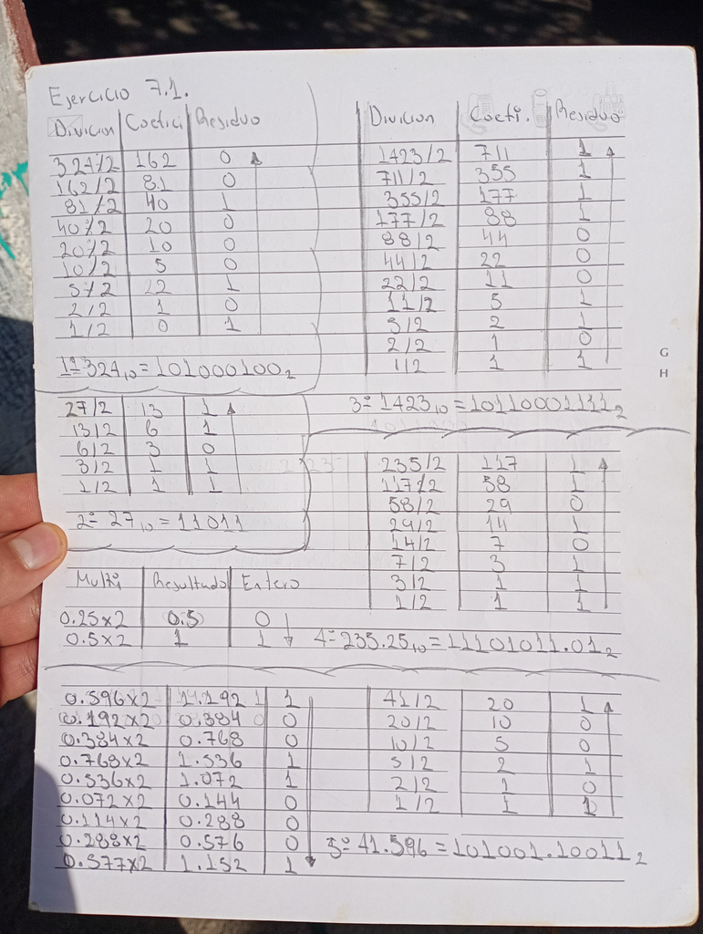

Ejercicio 7.2.:

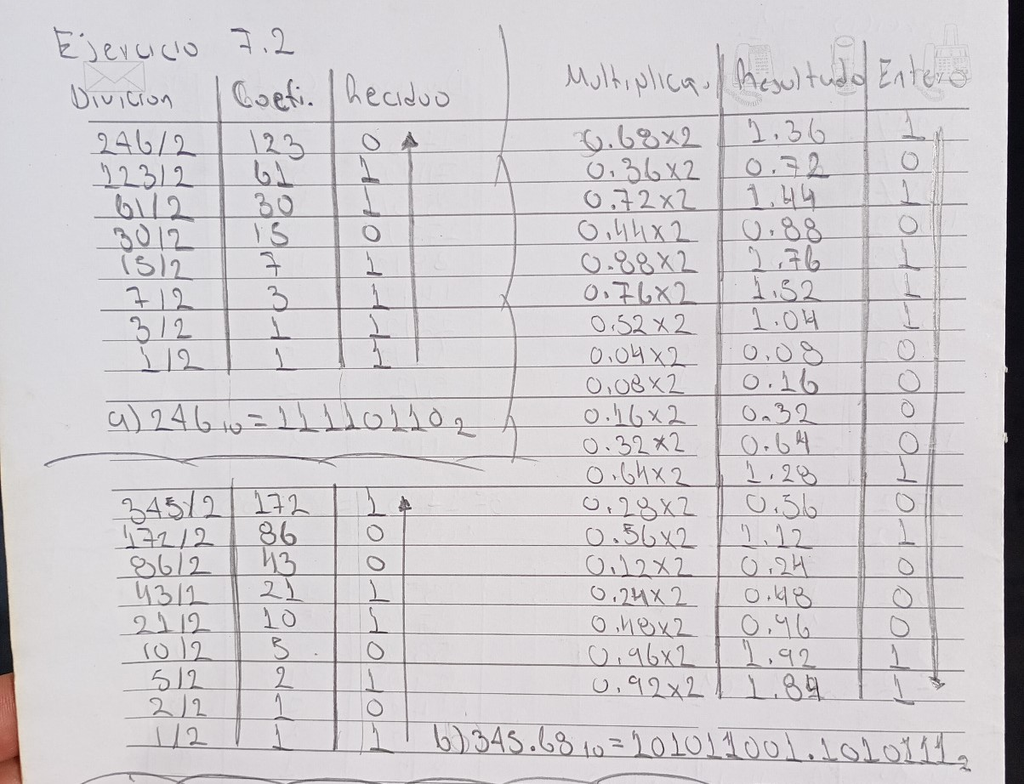

```r
# Número en base 10
num <- 4586632.2846

# Separar parte entera y fraccionaria
parte_entera <- floor(num)
parte_frac <- num - parte_entera

# ---- Conversión de parte entera ----
bin_entera <- c()
n <- parte_entera

while (n > 0) {
  bin_entera <- c(n %% 2, bin_entera)
  n <- n %/% 2
}

bin_entera <- paste(bin_entera, collapse = "")

# ---- Conversión de parte fraccionaria ----
bin_frac <- c()
f <- parte_frac
iter <- 30   # precisión: 30 bits fraccionarios

for (i in 1:iter) {
  f <- f * 2
  bit <- floor(f)
  bin_frac <- c(bin_frac, bit)
  f <- f - bit
}

bin_frac <- paste(bin_frac, collapse = "")

# ---- Resultado final ----
cat("Número en binario:\n")
```

```
## Número en binario:
```

```r
cat(bin_entera, ".", bin_frac, "\n", sep = "")
```

```
## 10001011111110010001000.010010001101101110001011101011
```

```r
# Número en base 10
num <- 984365.27463

# Separar parte entera y fraccionaria
parte_entera <- floor(num)
parte_frac <- num - parte_entera

# ---- Conversión de parte entera ----
bin_entera <- c()
n <- parte_entera

while (n > 0) {
  bin_entera <- c(n %% 2, bin_entera)
  n <- n %/% 2
}

bin_entera <- paste(bin_entera, collapse = "")

# ---- Conversión de parte fraccionaria ----
bin_frac <- c()
f <- parte_frac
iter <- 30   # precisión: 30 bits fraccionarios

for (i in 1:iter) {
  f <- f * 2
  bit <- floor(f)
  bin_frac <- c(bin_frac, bit)
  f <- f - bit
}

bin_frac <- paste(bin_frac, collapse = "")

# ---- Resultado final ----
cat("Número en binario:\n")
```

```
## Número en binario:
```

```r
cat(bin_entera, ".", bin_frac, "\n", sep = "")
```

```
## 11110000010100101101.010001100100111000100110110101
```

```r
# Número en base 10
num <- 79905523

# Separar parte entera y fraccionaria
parte_entera <- floor(num)
parte_frac <- num - parte_entera

# ---- Conversión de parte entera ----
bin_entera <- c()
n <- parte_entera

while (n > 0) {
  bin_entera <- c(n %% 2, bin_entera)
  n <- n %/% 2
}

bin_entera <- paste(bin_entera, collapse = "")

# ---- Conversión de parte fraccionaria ----
bin_frac <- c()
f <- parte_frac
iter <- 30   # precisión: 30 bits fraccionarios

for (i in 1:iter) {
  f <- f * 2
  bit <- floor(f)
  bin_frac <- c(bin_frac, bit)
  f <- f - bit
}

bin_frac <- paste(bin_frac, collapse = "")

# ---- Resultado final ----
cat("Número en binario:\n")
```

```
## Número en binario:
```

```r
cat(bin_entera, ".", bin_frac, "\n", sep = "")
```

```
## 100110000110100001011110011.000000000000000000000000000000
```

## Tipos de error

Incertidumbres: son inherentes a las dimensiones físicas que no pueden medirse con exactitud debido a la naturaleza de la materia y las imperfecciones en los instrumentos.

Verdaderas equivocaciones: son errores que ocurren durante la lectura de instrumentos o la transmisión de información.

Truncamiento: es causado por la imposibilidad de calcular con un número infinito de términos.

Redondeo: se produce durante el proceso de cálculo.

Error absoluto: es la diferencia entre el valor real y el valor aproximado.

Error relativo: se expresa como un porcentaje del error absoluto. Mientras que el error absoluto tiene dimensiones físicas, el error relativo es adimensional, lo que a menudo lo hace más comprensible en términos prácticos.

# Sistemas de Ecuaciones lineales

## Metodos Directos

### Gauss simple

#### Ejercicio 7.3.

```r
A <- matrix(c(
  1, -2, 0.5,
 -2,  5,-1.5,
 -0.2,1.75,-1
), nrow=3, byrow=TRUE)

b <- c(-5, 0, 10)

# ---- Eliminación ----
l21 = A[2,1]/A[1,1]
l31 = A[3,1]/A[1,1]

A[2,] = A[2,] - l21*A[1,]
A[3,] = A[3,] - l31*A[1,]

b[2] = b[2] - l21*b[1]
b[3] = b[3] - l31*b[1]

# Paso siguiente
l32 = A[3,2]/A[2,2]
A[3,] = A[3,] - l32*A[2,]
b[3] = b[3] - l32*b[2]

# ---- Sustitución ----
x3 = b[3]/A[3,3]
x2 = (b[2] - A[2,3]*x3)/A[2,2]
x1 = (b[1] - A[1,3]*x3 - A[1,2]*x2)/A[1,1]

c(x1,x2,x3)
```

```
## [1]  -75  -60 -100
```

```r
A <- matrix(c(
  3, -1,  0, 6,
  4,  2, -1,-5,
 -5,  1, -3, 0,
  0, 10,-4, 7
), nrow=4, byrow=TRUE)

b <- c(2.3, 6.9, -36, -36)

# ---- Paso 1 ----
l21=A[2,1]/A[1,1]; l31=A[3,1]/A[1,1]; l41=A[4,1]/A[1,1]

A[2,]=A[2,]-l21*A[1,]; b[2]=b[2]-l21*b[1]
A[3,]=A[3,]-l31*A[1,]; b[3]=b[3]-l31*b[1]
A[4,]=A[4,]-l41*A[1,]; b[4]=b[4]-l41*b[1]

# ---- Paso 2 ----
# pivote en fila 2
l32=A[3,2]/A[2,2]; l42=A[4,2]/A[2,2]

A[3,]=A[3,]-l32*A[2,]; b[3]=b[3]-l32*b[2]
A[4,]=A[4,]-l42*A[2,]; b[4]=b[4]-l42*b[2]

# ---- Paso 3 ----
l43=A[4,3]/A[3,3]
A[4,]=A[4,]-l43*A[3,]
b[4]=b[4]-l43*b[3]

# ---- Sustitución ----
x4=b[4]/A[4,4]
x3=(b[3]-A[3,4]*x4)/A[3,3]
x2=(b[2]-A[2,4]*x4-A[2,3]*x3)/A[2,2]
x1=(b[1]-A[1,4]*x4-A[1,3]*x3-A[1,2]*x2)/A[1,1]

c(x1,x2,x3,x4)
```

```
## [1]  2.5356223  0.1309013  7.8175966 -0.8626609
```

```r
A <- matrix(c(
  0.003000, 59.14,
  5.291000,-6.130
), nrow=2, byrow=TRUE)

b <- c(59.17, 46.78)

# Eliminación
l21 = A[2,1]/A[1,1]
A[2,] = A[2,] - l21*A[1,]
b[2] = b[2] - l21*b[1]

# Sustitución
x2 = b[2]/A[2,2]
x1 = (b[1] - A[1,2]*x2)/A[1,1]

signif(c(x1,x2),4)
```

```
## [1] 10  1
```

```r
A <- matrix(c(
 4, 2, 0,
 2, 3, 1,
 0, 1, 2.5
), nrow=3, byrow=TRUE)
b <- c(2, -1, 3)

# Eliminación
l21=A[2,1]/A[1,1]
A[2,]=A[2,]-l21*A[1,]; b[2]=b[2]-l21*b[1]

l31=A[3,2]/A[2,2]
A[3,]=A[3,]-l31*A[2,]; b[3]=b[3]-l31*b[2]

# Sustitución
x3=b[3]/A[3,3]
x2=(b[2]-A[2,3]*x3)/A[2,2]
x1=(b[1]-A[1,3]*x3-A[1,2]*x2)/A[1,1]

c(x1,x2,x3)
```

```
## [1]  1.5 -2.0  2.0
```

```r
A <- matrix(c(
 3,-0.1,-0.2,
 0.1, 7,-0.3,
 0.3,-0.2,10
), nrow=3, byrow=TRUE)

b <- c(7.85, -19.3, 71.4)

# Eliminación
l21=A[2,1]/A[1,1]; l31=A[3,1]/A[1,1]

A[2,]=A[2,]-l21*A[1,]; b[2]=b[2]-l21*b[1]
A[3,]=A[3,]-l31*A[1,]; b[3]=b[3]-l31*b[1]

l32=A[3,2]/A[2,2]
A[3,]=A[3,]-l32*A[2,]; b[3]=b[3]-l32*b[2]

# Sustitución
x3=b[3]/A[3,3]
x2=(b[2]-A[2,3]*x3)/A[2,2]
x1=(b[1]-A[1,3]*x3-A[1,2]*x2)/A[1,1]

c(x1,x2,x3)
```

```
## [1]  3.0 -2.5  7.0
```

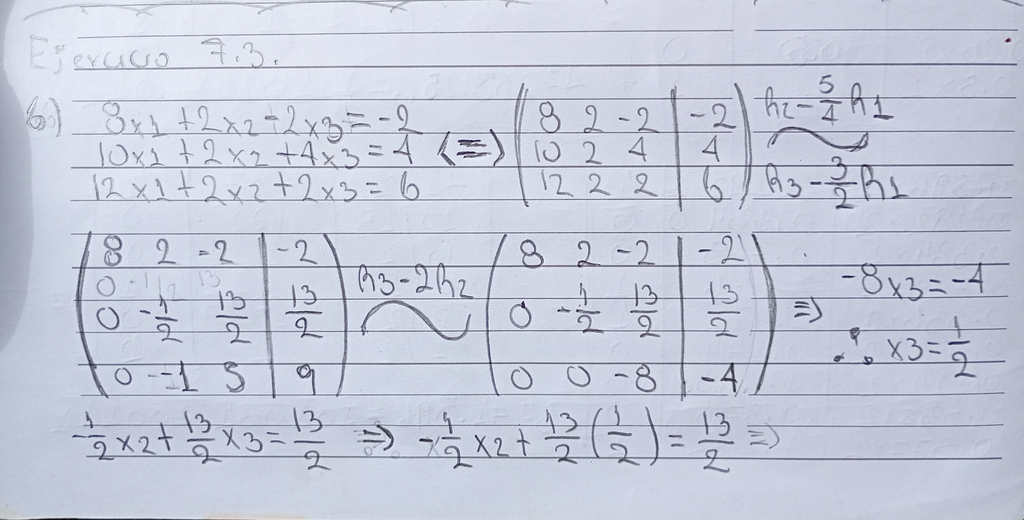

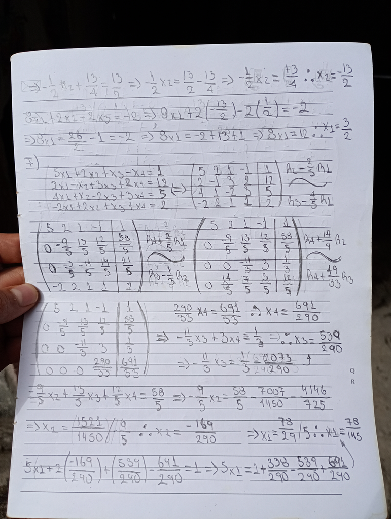

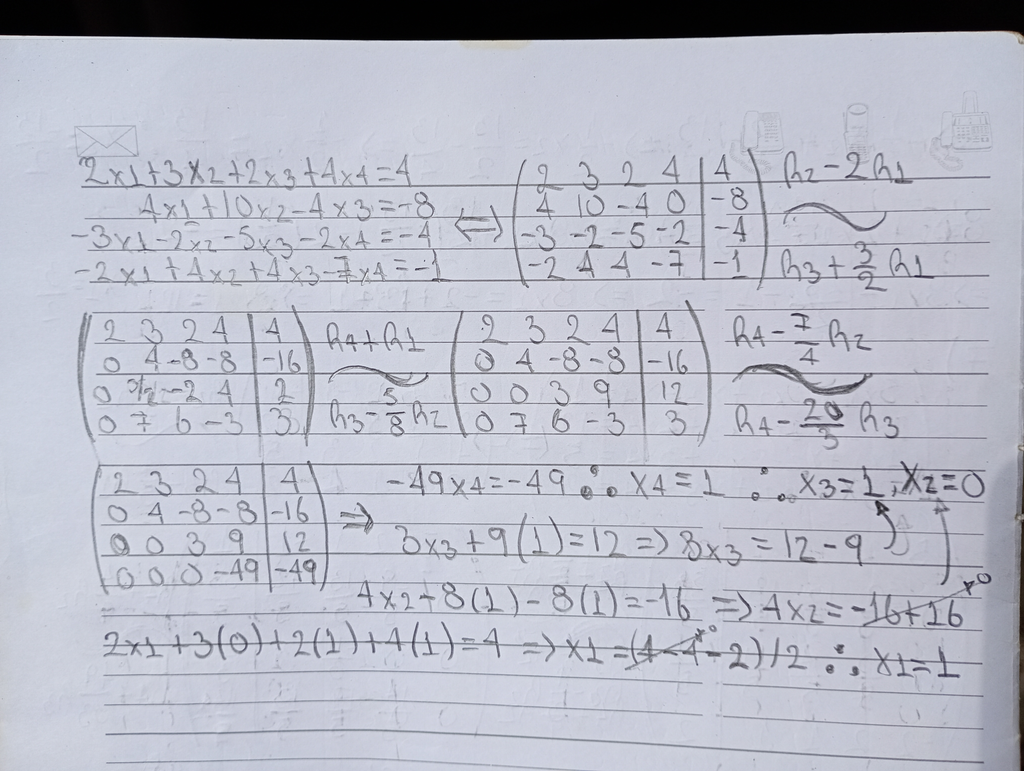

```r
A <- matrix(c(
 1.133, 5.281,-2.454,
24.14,-1.21, 5.281,
-10.123,6.387,-1
), nrow=3, byrow=TRUE)

b <- c(6.414,113.8,1)

# Paso 1
l21=A[2,1]/A[1,1]; l31=A[3,1]/A[1,1]

A[2,]=A[2,]-l21*A[1,]; b[2]=b[2]-l21*b[1]
A[3,]=A[3,]-l31*A[1,]; b[3]=b[3]-l31*b[1]

# Paso 2
l32=A[3,2]/A[2,2]
A[3,]=A[3,]-l32*A[2,]; b[3]=b[3]-l32*b[2]

# Sustitución
x3=b[3]/A[3,3]
x2=(b[2]-A[2,3]*x3)/A[2,2]
x1=(b[1]-A[1,3]*x3-A[1,2]*x2)/A[1,1]

c(x1,x2,x3)
```

```
## [1]  2.530346  5.943147 11.344189
```

```r
A <- matrix(c(
 2, 3, 2, 4,
 4,10,-4,0,
-3,-2,-5,-2,
-2, 4, 4,-7
), nrow=4, byrow=TRUE)

b <- c(9,-15,6,2)

# Paso 1
l21=A[2,1]/A[1,1]; l31=A[3,1]/A[1,1]; l41=A[4,1]/A[1,1]

A[2,]=A[2,]-l21*A[1,]; b[2]=b[2]-l21*b[1]
A[3,]=A[3,]-l31*A[1,]; b[3]=b[3]-l31*b[1]
A[4,]=A[4,]-l41*A[1,]; b[4]=b[4]-l41*b[1]

# Paso 2
l32=A[3,2]/A[2,2]; l42=A[4,2]/A[2,2]

A[3,]=A[3,]-l32*A[2,]; b[3]=b[3]-l32*b[2]
A[4,]=A[4,]-l42*A[2,]; b[4]=b[4]-l42*b[2]

# Paso 3
l43=A[4,3]/A[3,3]
A[4,]=A[4,]-l43*A[3,]
b[4]=b[4]-l43*b[3]

# Sustitución
x4=b[4]/A[4,4]
x3=(b[3]-A[3,4]*x4)/A[3,3]
x2=(b[2]-A[2,4]*x4-A[2,3]*x3)/A[2,2]
x1=(b[1]-A[1,4]*x4-A[1,3]*x3-A[1,2]*x2)/A[1,1]

c(x1,x2,x3,x4)
```

```
## [1] -8.232143  2.275510  1.206633  4.056122
```

### Gauss con pivoteo parcial

#### Ejercicio 7.4.

```r
rd <- function(x) signif(x,4)
A <- rd(matrix(c(
  0.4, -1.5,  0.75,
  -0.5, 15, 10,
  -10, -9,  2.5
), nrow=3, byrow=TRUE))
b <- rd(c(-20, -10, 30))

# Pivoteo columna 1
p = which.max(abs(A[,1]))
temp = A[1,]; A[1,] = A[p,]; A[p,] = temp
tb = b[1]; b[1] = b[p]; b[p] = tb

# Eliminación
l21 = rd(A[2,1]/A[1,1]); A[2,] = rd(A[2,] - l21*A[1,]); b[2] = rd(b[2] - l21*b[1])
l31 = rd(A[3,1]/A[1,1]); A[3,] = rd(A[3,] - l31*A[1,]); b[3] = rd(b[3] - l31*b[1])

# Pivoteo columna 2
p = 2 - 1 + which.max(abs(A[2:3,2]))
temp = A[2,]; A[2,] = A[p,]; A[p,] = temp
tb = b[2]; b[2] = b[p]; b[p] = tb

# Eliminación columna 2
l32 = rd(A[3,2]/A[2,2]); A[3,] = rd(A[3,] - l32*A[2,]); b[3] = rd(b[3] - l32*b[2])

# Sustitución
x3 = rd(b[3]/A[3,3])
x2 = rd((b[2] - A[2,3]*x3)/A[2,2])
x1 = rd((b[1] - A[1,2]*x2 - A[1,3]*x3)/A[1,1])
c(x1,x2,x3)
```

```
## [1] -10.500   5.581  -9.897
```

```r
rd <- function(x) signif(x, 4)

# Matriz de coeficientes y vector independiente
A <- rd(matrix(c(
  0.003000, 5.914,
  5.291000, -6.130
), nrow=2, byrow=TRUE))
b <- rd(c(59.17, 46.78))

# Pivoteo columna 1
p = which.max(abs(A[,1]))
temp = A[1,]; A[1,] = A[p,]; A[p,] = temp
tb = b[1]; b[1] = b[p]; b[p] = tb

# Eliminación
l21 = rd(A[2,1]/A[1,1])
A[2,] = rd(A[2,] - l21*A[1,])
b[2] = rd(b[2] - l21*b[1])

# Sustitución regresiva
x2 = rd(b[2]/A[2,2])
x1 = rd((b[1] - A[1,2]*x2)/A[1,1])

# Solución
c(x1, x2)
```

```
## [1] 20.420  9.995
```

```r
rd <- function(x) signif(x,4)

A <- rd(matrix(c(
 0.00031000, 1.00000000,
 1.00045534, 1.00034333
), nrow=2, byrow=TRUE))

b <- rd(c(3,7))

##### Pivoteo columna 1 #####
p <- which.max(abs(A[,1]))
temp=A[1,]; A[1,]=A[p,]; A[p]=temp
tb=b[1]; b[1]=b[p]; b[p]=tb

##### Eliminación #####
l21 <- rd(A[2,1]/A[1,1])

A[2,] <- rd(A[2,] - l21*A[1,])
b[2]  <- rd(b[2] - l21*b[1])

##### Sustitución #####
x2 <- rd(b[2]/A[2,2])
x1 <- rd((b[1] - A[1,2]*x2) / A[1,1])

c(x1,x2)
```

```
## [1] 4.001 2.999
```

```r
rd <- function(x) signif(x,4)

A <- rd(matrix(c(
 1/4,   1/5,   1/6,
 1/3,   1/4,   1/5,
 1/2,   1,  2
), nrow=3, byrow=TRUE))

b <- rd(c(9,8,8))

### Pivoteo columna 1 ###
p <- which.max(abs(A[,1]))
temp=A[1,]; A[1,]=A[p,]; A[p]=temp
tb=b[1]; b[1]=b[p]; b[p]=tb

### Eliminación ###
for(i in 2:3){
  l <- rd(A[i,1]/A[1,1])
  A[i,] <- rd(A[i,] - l*A[1,])
  b[i]  <- rd(b[i] - l*b[1])
}

### Segunda columna ###
p <- which.max(abs(A[2:3,2])) + 1
temp=A[2,]; A[2]=A[p,]; A[p]=temp
tb=b[2]; b[2]=b[p]; b[p]=tb

l32 <- rd(A[3,2]/A[2,2])
A[3,] <- rd(A[3,] - l32*A[2,])
b[3]  <- rd(b[3] - l32*b[2])

### Sustitución ###
x3 <- rd(b[3]/A[3,3])
x2 <- rd((b[2] - A[2,3]*x3)/A[2,2])
x1 <- rd((b[1] - A[1,2]*x2 - A[1,3]*x3)/A[1,1])

c(x1,x2,x3)
```

```
## [1]   5.32  53.54 -24.10
```

```r
rd <- function(x) signif(x,4)

# Matriz A y vector b (ejercicio 8)
A <- rd(matrix(c(
 1,   1/2,   1/3,   1/4,
 1/2,   1/3,   1/4,   1/5,
 1/3,   1/4,   1/5,   1/6,
 1/4,   1/5,   1/6,   1/7
), nrow=4, byrow=TRUE))

b <- rd(c(1/6, 1/7, 1/8, 1/9))

n <- nrow(A)

##### Eliminación (Gauss con pivoteo parcial) #####
for(k in 1:n){
  # pivoteo parcial: busca el mayor abs en la subcolumna k:k, fila k..n
  subindex <- k:n
  p_rel <- which.max(abs(A[subindex, k]))
  p <- subindex[p_rel]
  # intercambio de filas k y p en A y en b (si p != k)
  if(p != k){
    temp <- A[k,]; A[k,] <- A[p,]; A[p,] <- temp
    tb <- b[k]; b[k] <- b[p]; b[p] <- tb
  }
  # eliminación solo si quedan filas debajo
  if(k < n){
    for(i in (k+1):n){
      # si el pivote es cero (singular), saltamos para evitar división por 0
      if(A[k,k] == 0){
        stop("Pivote nulo detectado en fila ", k, ". Sistema singular o requiere reordenamiento.")
      }
      l <- rd(A[i,k]/A[k,k])
      A[i,] <- rd(A[i,] - l*A[k,])
      b[i]  <- rd(b[i] - l*b[k])
    }
  }
}

##### Sustitución hacia atrás #####
x <- numeric(n)
for(i in n:1){
  if(i == n){
    # cuando no hay términos a la derecha, suma = 0
    suma <- 0
  } else {
    suma <- sum(A[i,(i+1):n]*x[(i+1):n])
  }
  x[i] <- rd((b[i] - suma) / A[i,i])
}

# Mostrar la solución
print(x)
```

```
## [1] -0.05592  0.84670 -2.95900  3.14200
```

```r
rd <- function(x) signif(x, 4)
A <- rd(matrix(c(
  2, 1, -1, 1, -3,
  1, 0, 2, -1, 1,
  0, -2, -1, 1, -1,
  3, 1, -4, 0, 5,
  1, -1, -1, -1, 1
), nrow=5, byrow=TRUE))
b <- rd(c(7, 2, -5, 6, 3))

##### Pivoteo columna 1 #####
p = which.max(abs(A[,1]))
temp = A[1,]; A[1,] = A[p,]; A[p,] = temp
tb = b[1]; b[1] = b[p]; b[p] = tb

##### Eliminación #####
l21 = rd(A[2,1]/A[1,1]); A[2,] = rd(A[2,] - l21*A[1,]); b[2] = rd(b[2] - l21*b[1])
l31 = rd(A[3,1]/A[1,1]); A[3,] = rd(A[3,] - l31*A[1,]); b[3] = rd(b[3] - l31*b[1])
l41 = rd(A[4,1]/A[1,1]); A[4,] = rd(A[4,] - l41*A[1,]); b[4] = rd(b[4] - l41*b[1])
l51 = rd(A[5,1]/A[1,1]); A[5,] = rd(A[5,] - l51*A[1,]); b[5] = rd(b[5] - l51*b[1])

##### Pivoteo columna 2 #####
p = 2 - 1 + which.max(abs(A[2:5,2]))
temp = A[2,]; A[2,] = A[p,]; A[p,] = temp
tb = b[2]; b[2] = b[p]; b[p] = tb

##### Eliminación columna 2 #####
l32 = rd(A[3,2]/A[2,2]); A[3,] = rd(A[3,] - l32*A[2,]); b[3] = rd(b[3] - l32*b[2])
l42 = rd(A[4,2]/A[2,2]); A[4,] = rd(A[4,] - l42*A[2,]); b[4] = rd(b[4] - l42*b[2])
l52 = rd(A[5,2]/A[2,2]); A[5,] = rd(A[5,] - l52*A[2,]); b[5] = rd(b[5] - l52*b[2])

##### Pivoteo columna 3 #####
p = 3 - 1 + which.max(abs(A[3:5,3]))
temp = A[3,]; A[3,] = A[p,]; A[p,] = temp
tb = b[3]; b[3] = b[p]; b[p] = tb

##### Eliminación columna 3 #####
l43 = rd(A[4,3]/A[3,3]); A[4,] = rd(A[4,] - l43*A[3,]); b[4] = rd(b[4] - l43*b[3])
l53 = rd(A[5,3]/A[3,3]); A[5,] = rd(A[5,] - l53*A[3,]); b[5] = rd(b[5] - l53*b[3])

##### Pivoteo columna 4 #####
p = 4 - 1 + which.max(abs(A[4:5,4]))
temp = A[4,]; A[4,] = A[p,]; A[p,] = temp
tb = b[4]; b[4] = b[p]; b[p] = tb

##### Eliminación columna 4 #####
l54 = rd(A[5,4]/A[4,4]); A[5,] = rd(A[5,] - l54*A[4,]); b[5] = rd(b[5] - l54*b[4])

##### Sustitución regresiva #####
x5 = rd(b[5]/A[5,5])
x4 = rd((b[4] - A[4,5]*x5)/A[4,4])
x3 = rd((b[3] - A[3,4]*x4 - A[3,5]*x5)/A[3,3])
x2 = rd((b[2] - A[2,3]*x3 - A[2,4]*x4 - A[2,5]*x5)/A[2,2])
x1 = rd((b[1] - A[1,2]*x2 - A[1,3]*x3 - A[1,4]*x4 - A[1,5]*x5)/A[1,1])

c(x1, x2, x3, x4, x5)
```

```
## [1]  1.9170  1.9650 -0.9894 -3.1950 -1.1350
```

```r
rd <- function(x) signif(x, 4)
A <- rd(matrix(c(
  3.333, 15920, -10.333,
  2.222, 16.71, 9.612,
  1.5611, 5.1791, 1.6852
), nrow=3, byrow=TRUE))
b <- rd(c(15913, 28.544, 8.4254))

##### Pivoteo columna 1 #####
p = which.max(abs(A[,1]))
temp = A[1,]; A[1,] = A[p,]; A[p,] = temp
tb = b[1]; b[1] = b[p]; b[p] = tb

##### Eliminación #####
l21 = rd(A[2,1]/A[1,1]); A[2,] = rd(A[2,] - l21*A[1,]); b[2] = rd(b[2] - l21*b[1])
l31 = rd(A[3,1]/A[1,1]); A[3,] = rd(A[3,] - l31*A[1,]); b[3] = rd(b[3] - l31*b[1])

##### Pivoteo columna 2 #####
p = 2 - 1 + which.max(abs(A[2:3,2]))
temp = A[2,]; A[2,] = A[p,]; A[p,] = temp
tb = b[2]; b[2] = b[p]; b[p] = tb

##### Eliminación columna 2 #####
l32 = rd(A[3,2]/A[2,2]); A[3,] = rd(A[3,] - l32*A[2,]); b[3] = rd(b[3] - l32*b[2])

##### Sustitución #####
x3 = rd(b[3]/A[3,3])
x2 = rd((b[2] - A[2,3]*x3)/A[2,2])
x1 = rd((b[1] - A[1,2]*x2 - A[1,3]*x3)/A[1,1])
c(x1,x2,x3)
```

```
## [1] 0.8955 1.0000 1.2570
```

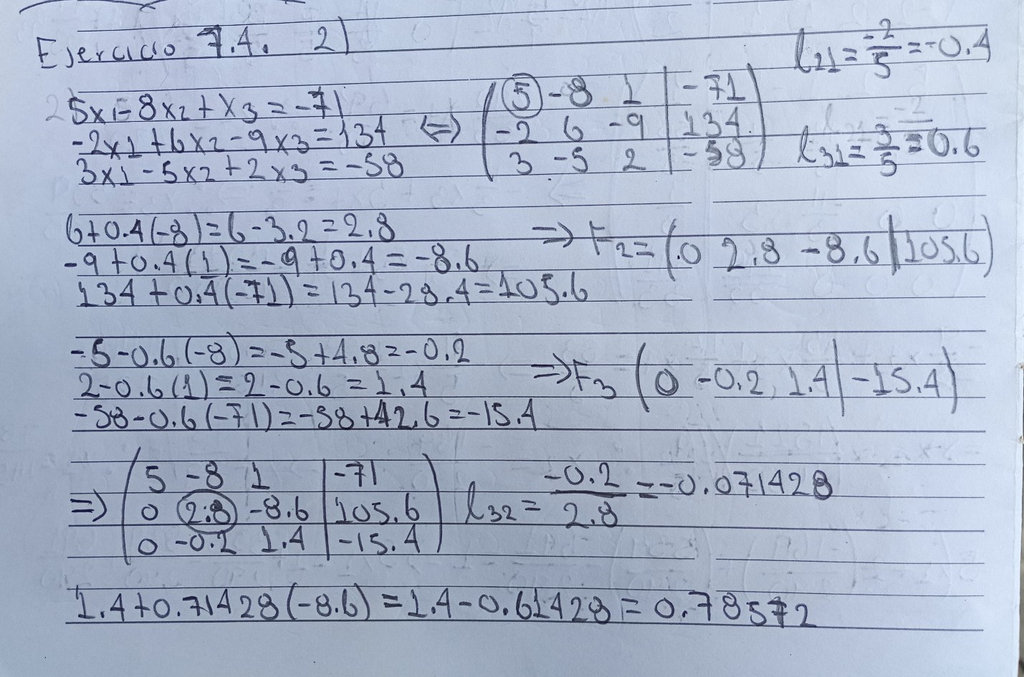

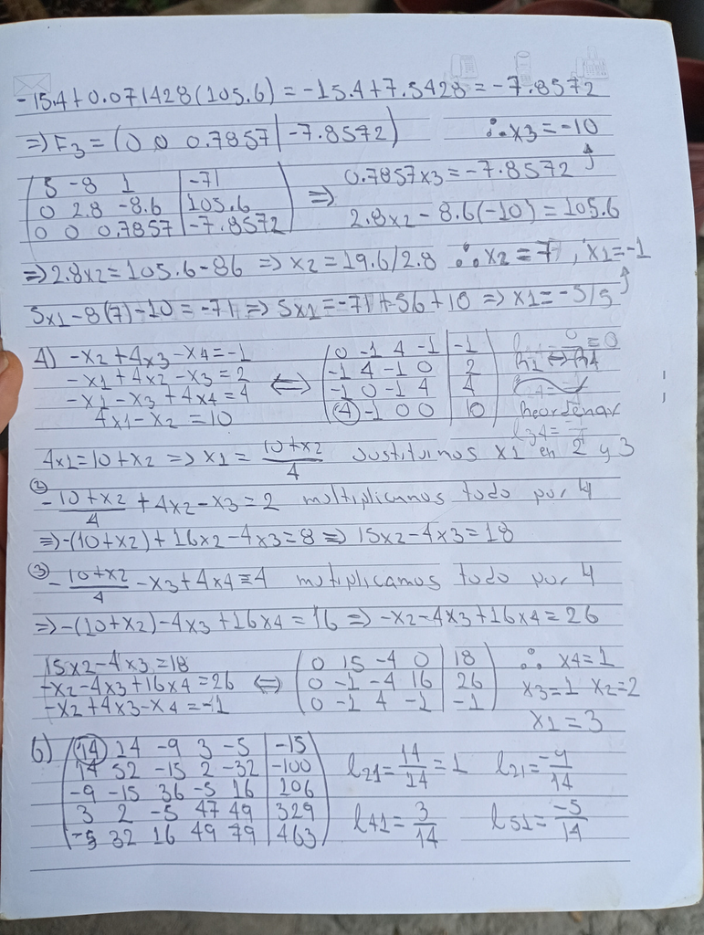

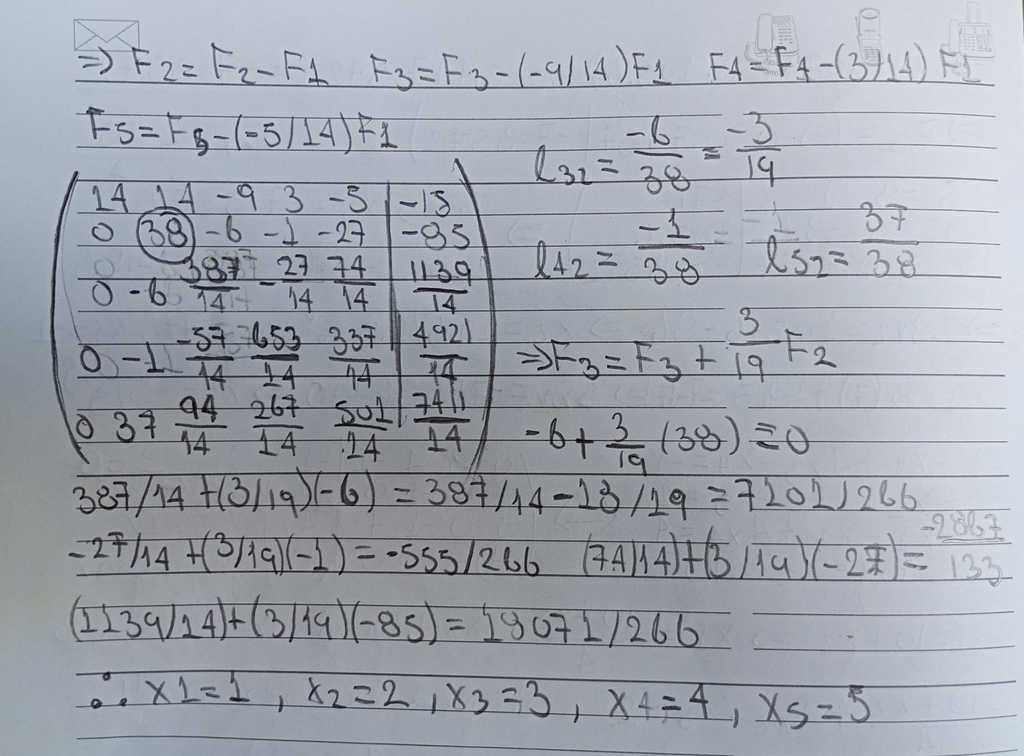

## Metodos Interativos

### Gauss-Jordan

#### Ejercicio 7.5.

```r
# Sistema 1
A = matrix(c(1, 2, 3, -0.4, 2, -1, 0.5, -3, 1), nrow = 3, byrow = TRUE)
b = matrix(c(1, 10, 15), nrow = 3, byrow = TRUE)
Ab <- cbind(A, b); (Ab)
```

```
##      [,1] [,2] [,3] [,4]
## [1,]  1.0    2    3    1
## [2,] -0.4    2   -1   10
## [3,]  0.5   -3    1   15
```

```r
# Paso 1: Eliminación
l21 = A[2,1]/A[1,1]
l31 = A[3,1]/A[1,1]

A[2,] = A[2,] - l21*A[1,]
A[3,] = A[3,] - l31*A[1,]
b[2] = b[2] - l21*b[1]
b[3] = b[3] - l31*b[1]

# Paso 2
l32 = A[3,2]/A[2,2]
A[3,] = A[3,] - l32*A[2,]
b[3] = b[3] - l32*b[2]

# Paso 3: Sustitución hacia atrás
x3 = b[3] / A[3,3]
x2 = (b[2] - A[2,3]*x3) / A[2,2]
x1 = (b[1] - A[1,3]*x3 - A[1,2]*x2) / A[1,1]

cat("Solución Sistema 1:\n")
```

```
## Solución Sistema 1:
```

```r
cat("x1 =", x1, "\n")
```

```
## x1 = 385
```

```r
cat("x2 =", x2, "\n")
```

```
## x2 = 13.5
```

```r
cat("x3 =", x3, "\n")
```

```
## x3 = -137
```

```r
# Sistema 2
A = matrix(c(2, -0.9, 3, -0.5, 0.1, -1, 1, -6.35, -0.45), nrow = 3, byrow = TRUE)
b = matrix(c(-3.61, 2.035, 15.401), nrow = 3, byrow = TRUE)
Ab <- cbind(A, b); (Ab)
```

```
##      [,1]  [,2]  [,3]   [,4]
## [1,]  2.0 -0.90  3.00 -3.610
## [2,] -0.5  0.10 -1.00  2.035
## [3,]  1.0 -6.35 -0.45 15.401
```

```r
# Paso 1
l21 = A[2,1]/A[1,1]
l31 = A[3,1]/A[1,1]

A[2,] = A[2,] - l21*A[1,]
A[3,] = A[3,] - l31*A[1,]
b[2] = b[2] - l21*b[1]
b[3] = b[3] - l31*b[1]

# Paso 2
l32 = A[3,2]/A[2,2]
A[3,] = A[3,] - l32*A[2,]
b[3] = b[3] - l32*b[2]

# Sustitución hacia atrás
x3 = b[3] / A[3,3]
x2 = (b[2] - A[2,3]*x3) / A[2,2]
x1 = (b[1] - A[1,3]*x3 - A[1,2]*x2) / A[1,1]

cat("Solución Sistema 2:\n")
```

```
## Solución Sistema 2:
```

```r
cat("x1 =", x1, "\n")
```

```
## x1 = 2.95
```

```r
cat("x2 =", x2, "\n")
```

```
## x2 = -1.7
```

```r
cat("x3 =", x3, "\n")
```

```
## x3 = -3.68
```

```r
# Sistema 3
A = matrix(c(0.7, 2.7, -6, 0.7, 2, -0.8, 3, -1, -1, -1.5, 1.4, 3, 0, 7, -1.56, 1), nrow = 4, byrow = TRUE)
b = matrix(c(1.6487, -2.342, -4.189, 15.792), nrow = 4, byrow = TRUE)
Ab <- cbind(A, b); (Ab)
```

```
##      [,1] [,2]  [,3] [,4]    [,5]
## [1,]  0.7  2.7 -6.00  0.7  1.6487
## [2,]  2.0 -0.8  3.00 -1.0 -2.3420
## [3,] -1.0 -1.5  1.40  3.0 -4.1890
## [4,]  0.0  7.0 -1.56  1.0 15.7920
```

```r
# Paso 1
l21 = A[2,1]/A[1,1]
l31 = A[3,1]/A[1,1]
l41 = A[4,1]/A[1,1]

A[2,] = A[2,] - l21*A[1,]
A[3,] = A[3,] - l31*A[1,]
A[4,] = A[4,] - l41*A[1,]
b[2] = b[2] - l21*b[1]
b[3] = b[3] - l31*b[1]
b[4] = b[4] - l41*b[1]

# Intercambio si necesario
temp = A[2,]; A[2,] = A[3,]; A[3,] = temp
tmp_b = b[2]; b[2] = b[3]; b[3] = tmp_b

# Paso 2
l32 = A[3,2]/A[2,2]
l42 = A[4,2]/A[2,2]

A[3,] = A[3,] - l32*A[2,]
A[4,] = A[4,] - l42*A[2,]
b[3] = b[3] - l32*b[2]
b[4] = b[4] - l42*b[2]

# Paso 3
A[3,] = A[3,] / A[3,3]
b[3] = b[3] / A[3,3]

l43 = A[4,3]/A[3,3]
A[4,] = A[4,] - l43*A[3,]
b[4] = b[4] - l43*b[3]

# Sustitución hacia atrás
x4 = b[4] / A[4,4]
x3 = (b[3] - A[3,4]*x4) / A[3,3]
x2 = (b[2] - A[2,4]*x4 - A[2,3]*x3) / A[2,2]
x1 = (b[1] - A[1,4]*x4 - A[1,3]*x3 - A[1,2]*x2) / A[1,1]

cat("Solución Sistema 3:\n")
```

```
## Solución Sistema 3:
```

```r
cat("x1 =", x1, "\n")
```

```
## x1 = 41.00762
```

```r
cat("x2 =", x2, "\n")
```

```
## x2 = 2.290121
```

```r
cat("x3 =", x3, "\n")
```

```
## x3 = 6.738542
```

```r
cat("x4 =", x4, "\n")
```

```
## x4 = 10.27328
```

```r
# Sistema 4
A = matrix(c(3, -0.1, -0.2, 0.1, 7, -0.3, 0.3, -0.2, 10), nrow = 3, byrow = TRUE)
b = matrix(c(7.85, -19.3, 71.4), nrow = 3, byrow = TRUE)
Ab <- cbind(A, b); (Ab)
```

```
##      [,1] [,2] [,3]   [,4]
## [1,]  3.0 -0.1 -0.2   7.85
## [2,]  0.1  7.0 -0.3 -19.30
## [3,]  0.3 -0.2 10.0  71.40
```

```r
# Paso 1: Eliminación
l21 = A[2,1]/A[1,1]
l31 = A[3,1]/A[1,1]

A[2,] = A[2,] - l21*A[1,]
A[3,] = A[3,] - l31*A[1,]
b[2] = b[2] - l21*b[1]
b[3] = b[3] - l31*b[1]

# Paso 2
l32 = A[3,2]/A[2,2]
A[3,] = A[3,] - l32*A[2,]
b[3] = b[3] - l32*b[2]

# Sustitución hacia atrás
x3 = b[3] / A[3,3]
x2 = (b[2] - A[2,3]*x3) / A[2,2]
x1 = (b[1] - A[1,3]*x3 - A[1,2]*x2) / A[1,1]

cat("Solución Sistema 4:\n")
```

```
## Solución Sistema 4:
```

```r
cat("x1 =", x1, "\n")
```

```
## x1 = 3
```

```r
cat("x2 =", x2, "\n")
```

```
## x2 = -2.5
```

```r
cat("x3 =", x3, "\n")
```

```
## x3 = 7
```

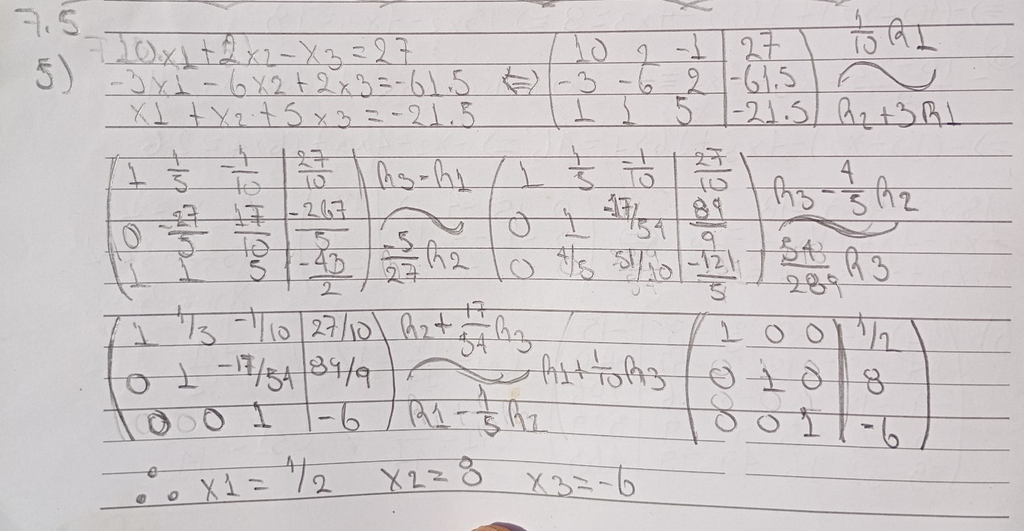

Ejercicio 5 Gauss-Jordan

```r
# Sistema 6
A = matrix(c(1, 3, -2, 1, 1, 3, -1, 2, 0, 1, -1, 4, 2, 6, 1, 2), nrow = 4, byrow = TRUE)
b = matrix(c(4, 1, 5, 2), nrow = 4, byrow = TRUE)
Ab <- cbind(A, b); (Ab)
```

```
##      [,1] [,2] [,3] [,4] [,5]
## [1,]    1    3   -2    1    4
## [2,]    1    3   -1    2    1
## [3,]    0    1   -1    4    5
## [4,]    2    6    1    2    2
```

```r
# Paso 1
l21 = A[2,1]/A[1,1]
l31 = A[3,1]/A[1,1]
l41 = A[4,1]/A[1,1]

A[2,] = A[2,] - l21*A[1,]
A[3,] = A[3,] - l31*A[1,]
A[4,] = A[4,] - l41*A[1,]
b[2] = b[2] - l21*b[1]
b[3] = b[3] - l31*b[1]
b[4] = b[4] - l41*b[1]

# Intercambio si necesario
temp = A[2,]; A[2,] = A[3,]; A[3,] = temp
tmp_b = b[2]; b[2] = b[3]; b[3] = tmp_b

# Paso 2
l32 = A[3,2]/A[2,2]
l42 = A[4,2]/A[2,2]

A[3,] = A[3,] - l32*A[2,]
A[4,] = A[4,] - l42*A[2,]
b[3] = b[3] - l32*b[2]
b[4] = b[4] - l42*b[2]

# Paso 3
A[3,] = A[3,] / A[3,3]
b[3] = b[3] / A[3,3]

l43 = A[4,3]/A[3,3]
A[4,] = A[4,] - l43*A[3,]
b[4] = b[4] - l43*b[3]

# Sustitución hacia atrás
x4 = b[4] / A[4,4]
x3 = (b[3] - A[3,4]*x4) / A[3,3]
x2 = (b[2] - A[2,4]*x4 - A[2,3]*x3) / A[2,2]
x1 = (b[1] - A[1,4]*x4 - A[1,3]*x3 - A[1,2]*x2) / A[1,1]

cat("Solución Sistema 6:\n")
```

```
## Solución Sistema 6:
```

```r
cat("x1 =", x1, "\n")
```

```
## x1 = -29.6
```

```r
cat("x2 =", x2, "\n")
```

```
## x2 = 11
```

```r
cat("x3 =", x3, "\n")
```

```
## x3 = -1.2
```

```r
cat("x4 =", x4, "\n")
```

```
## x4 = -1.8
```

```r
# Sistema 7
A = matrix(c(6, -1, -1, 4,
             1, -10, 2, -1,
             3, -2, 8, -1,
             1, 1, 1, -5), nrow = 4, byrow = TRUE)
b = matrix(c(17, -17, 19, -14), nrow = 4, byrow = TRUE)
Ab <- cbind(A, b); (Ab)
```

```
##      [,1] [,2] [,3] [,4] [,5]
## [1,]    6   -1   -1    4   17
## [2,]    1  -10    2   -1  -17
## [3,]    3   -2    8   -1   19
## [4,]    1    1    1   -5  -14
```

```r
# Paso 1: Eliminación
l21 = A[2,1]/A[1,1]
l31 = A[3,1]/A[1,1]
l41 = A[4,1]/A[1,1]

A[2,] = A[2,] - l21*A[1,]
A[3,] = A[3,] - l31*A[1,]
A[4,] = A[4,] - l41*A[1,]
b[2] = b[2] - l21*b[1]
b[3] = b[3] - l31*b[1]
b[4] = b[4] - l41*b[1]

# Intercambio si necesario
temp = A[2,]; A[2,] = A[3,]; A[3,] = temp
tmp_b = b[2]; b[2] = b[3]; b[3] = tmp_b

# Paso 2
l32 = A[3,2]/A[2,2]
l42 = A[4,2]/A[2,2]

A[3,] = A[3,] - l32*A[2,]
A[4,] = A[4,] - l42*A[2,]
b[3] = b[3] - l32*b[2]
b[4] = b[4] - l42*b[2]

# Paso 3
A[3,] = A[3,] / A[3,3]
b[3] = b[3] / A[3,3]

l43 = A[4,3]/A[3,3]
A[4,] = A[4,] - l43*A[3,]
b[4] = b[4] - l43*b[3]

# Sustitución hacia atrás
x4 = b[4] / A[4,4]
x3 = (b[3] - A[3,4]*x4) / A[3,3]
x2 = (b[2] - A[2,4]*x4 - A[2,3]*x3) / A[2,2]
x1 = (b[1] - A[1,4]*x4 - A[1,3]*x3 - A[1,2]*x2) / A[1,1]

cat("Solución del sistema 7:\n")
```

```
## Solución del sistema 7:
```

```r
cat("x1 =", x1, "\n")
```

```
## x1 = -17.63351
```

```r
cat("x2 =", x2, "\n")
```

```
## x2 = -497.3781
```

```r
cat("x3 =", x3, "\n")
```

```
## x3 = -131.1613
```

```r
cat("x4 =", x4, "\n")
```

```
## x4 = -126.4346
```

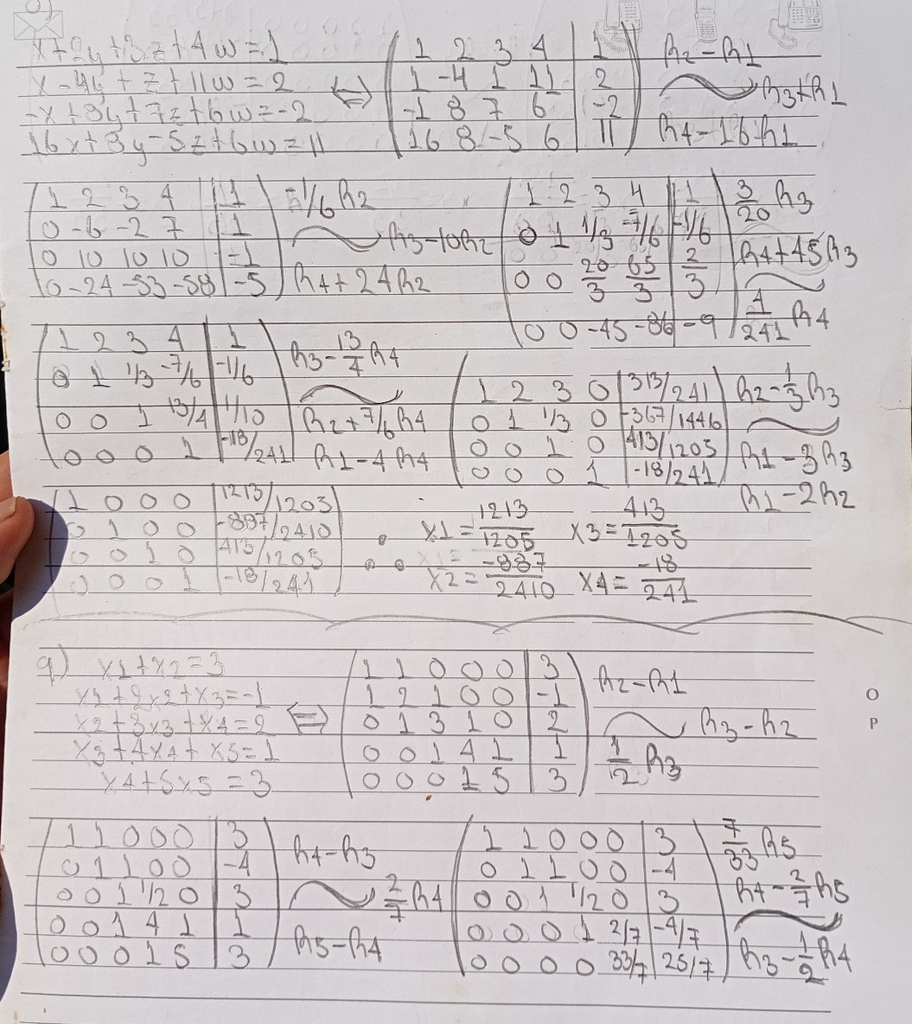

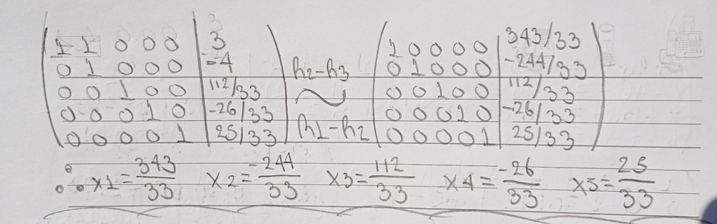

```r
# Sistema final
A = matrix(c(15, -18, 15, -3,
             -18, 24, -18, 4,
             15, -18, 18, -3,
             -3, 4, -3, 1), nrow = 4, byrow = TRUE)
b = matrix(c(11, 10, 11, 13), nrow = 4, byrow = TRUE)
Ab <- cbind(A, b); (Ab)
```

```
##      [,1] [,2] [,3] [,4] [,5]
## [1,]   15  -18   15   -3   11
## [2,]  -18   24  -18    4   10
## [3,]   15  -18   18   -3   11
## [4,]   -3    4   -3    1   13
```

```r
# Paso 1: Eliminación
l21 = A[2,1]/A[1,1]
l31 = A[3,1]/A[1,1]
l41 = A[4,1]/A[1,1]

A[2,] = A[2,] - l21*A[1,]
A[3,] = A[3,] - l31*A[1,]
A[4,] = A[4,] - l41*A[1,]
b[2] = b[2] - l21*b[1]
b[3] = b[3] - l31*b[1]
b[4] = b[4] - l41*b[1]

# Intercambio si necesario
temp = A[2,]; A[2,] = A[3,]; A[3,] = temp
tmp_b = b[2]; b[2] = b[3]; b[3] = tmp_b

# Paso 2
l32 = A[3,2]/A[2,2]
l42 = A[4,2]/A[2,2]

A[3,] = A[3,] - l32*A[2,]
A[4,] = A[4,] - l42*A[2,]
b[3] = b[3] - l32*b[2]
b[4] = b[4] - l42*b[2]

# Paso 3
A[3,] = A[3,] / A[3,3]
b[3] = b[3] / A[3,3]

l43 = A[4,3]/A[3,3]
A[4,] = A[4,] - l43*A[3,]
b[4] = b[4] - l43*b[3]

# Sustitución hacia atrás
x4 = b[4] / A[4,4]
x3 = (b[3] - A[3,4]*x4) / A[3,3]
x2 = (b[2] - A[2,4]*x4 - A[2,3]*x3) / A[2,2]
x1 = (b[1] - A[1,4]*x4 - A[1,3]*x3 - A[1,2]*x2) / A[1,1]

cat("Solución del sistema:\n")
```

```
## Solución del sistema:
```

```r
cat("x1 =", x1, "\n")
```

```
## x1 = NaN
```

```r
cat("x2 =", x2, "\n")
```

```
## x2 = NaN
```

```r
cat("x3 =", x3, "\n")
```

```
## x3 = NaN
```

```r
cat("x4 =", x4, "\n")
```

```
## x4 = NaN
```

```r
print("Matriz A después de la eliminación:")
```

```
## [1] "Matriz A después de la eliminación:"
```

```r
print(A)
```

```
##      [,1] [,2] [,3] [,4]
## [1,]   15  -18   15   -3
## [2,]    0    0    3    0
## [3,]  NaN  NaN  NaN  NaN
## [4,]  NaN  NaN  NaN  NaN
```

```r
print("Vector b después de la eliminación:")
```

```
## [1] "Vector b después de la eliminación:"
```

```r
print(b)
```

```
##      [,1]
## [1,]   11
## [2,]    0
## [3,]  NaN
## [4,]  NaN
```

### Gauss-seidel

#### Ejercicio 7.6.

```r
# Sistema 1
A = matrix(c(3, -0.2, -0.5,
             0.1, 7, 0.4,
             0.4, -0.1, 10), nrow = 3, byrow = TRUE)
b = matrix(c(8, -19.5, 72.4), nrow = 3, byrow = TRUE)
Ab <- cbind(A, b); (Ab)
```

```
##      [,1] [,2] [,3]  [,4]
## [1,]  3.0 -0.2 -0.5   8.0
## [2,]  0.1  7.0  0.4 -19.5
## [3,]  0.4 -0.1 10.0  72.4
```

```r
# Valores iniciales
x1 = 0; x2 = 0; x3 = 0

# Iteraciones Gauss-Seidel
for (iter in 1:20) {
  x1_old = x1; x2_old = x2; x3_old = x3

  x1 = (b[1] - A[1,2]*x2 - A[1,3]*x3) / A[1,1]
  x2 = (b[2] - A[2,1]*x1 - A[2,3]*x3) / A[2,2]
  x3 = (b[3] - A[3,1]*x1 - A[3,2]*x2) / A[3,3]

  cat("Iteración", iter, ": x1 =", round(x1,4), "x2 =", round(x2,4), "x3 =", round(x3,4), "\n")

  if (sqrt((x1 - x1_old)^2 + (x2 - x2_old)^2 + (x3 - x3_old)^2) < 1e-6) break
}
```

```
## Iteración 1 : x1 = 2.6667 x2 = -2.8238 x3 = 7.1051
## Iteración 2 : x1 = 3.6626 x2 = -3.244 x3 = 7.0611
## Iteración 3 : x1 = 3.6272 x2 = -3.241 x3 = 7.0625
## Iteración 4 : x1 = 3.6277 x2 = -3.2411 x3 = 7.0625
## Iteración 5 : x1 = 3.6277 x2 = -3.2411 x3 = 7.0625
## Iteración 6 : x1 = 3.6277 x2 = -3.2411 x3 = 7.0625
```

```r
# Sistema 2
A = matrix(c(-5, 1.4, -2.7,
             0.7, -2.5, 15,
             3.3, -11, 4.4), nrow = 3, byrow = TRUE)
b = matrix(c(94.2, -6, -27.5), nrow = 3, byrow = TRUE)
Ab <- cbind(A, b); (Ab)
```

```
##      [,1]  [,2] [,3]  [,4]
## [1,] -5.0   1.4 -2.7  94.2
## [2,]  0.7  -2.5 15.0  -6.0
## [3,]  3.3 -11.0  4.4 -27.5
```

```r
x1 = 0; x2 = 0; x3 = 0

for (iter in 1:20) {
  x1_old = x1; x2_old = x2; x3_old = x3

  x1 = (b[1] - A[1,2]*x2 - A[1,3]*x3) / A[1,1]
  x2 = (b[2] - A[2,1]*x1 - A[2,3]*x3) / A[2,2]
  x3 = (b[3] - A[3,1]*x1 - A[3,2]*x2) / A[3,3]

  cat("Iteración", iter, ": x1 =", round(x1,4), "x2 =", round(x2,4), "x3 =", round(x3,4), "\n")

  if (sqrt((x1 - x1_old)^2 + (x2 - x2_old)^2 + (x3 - x3_old)^2) < 1e-6) break
}
```

```
## Iteración 1 : x1 = -18.84 x2 = -2.8752 x3 = 0.692
## Iteración 2 : x1 = -20.0187 x2 = 0.9468 x3 = 11.1309
## Iteración 3 : x1 = -24.5856 x2 = 62.3016 x3 = 167.9433
## Iteración 4 : x1 = -92.0849 x2 = 984.2762 x3 = 2523.504
## Iteración 5 : x1 = -1105.935 x2 = 14833.76 x3 = 37907.61
## Iteración 6 : x1 = -16335.5 x2 = 222874.1 x3 = 569430.7
## Iteración 7 : x1 = -245106.7 x2 = 3347957 x3 = 8553715
## Iteración 8 : x1 = -3681597 x2 = 50291447 x3 = 128489809
## Iteración 9 : x1 = -55302910 x2 = 755454040 x3 = 1930112277
## Iteración 10 : x1 = -830733517 x2 = 11348068277 x3 = 28993220823
## Iteración 11 : x1 = -12478880146 x2 = 170465238501 x3 = 435522256355
## Iteración 12 : x1 = -187451751670 x2 = 2.560647e+12 x3 = 6.542206e+12
## Iteración 13 : x1 = -2.81581e+12 x2 = 3.846481e+13 x3 = 9.827389e+13
## Iteración 14 : x1 = -4.229775e+13 x2 = 5.778e+14 x3 = 1.476223e+15
## Iteración 15 : x1 = -6.353765e+14 x2 = 8.679434e+15 x3 = 2.217512e+16
## Iteración 16 : x1 = -9.544322e+15 x2 = 1.303783e+17 x3 = 3.33104e+17
## Iteración 17 : x1 = -1.433702e+17 x2 = 1.95848e+18 x3 = 5.003728e+18
## Iteración 18 : x1 = -2.153639e+18 x2 = 2.941935e+19 x3 = 7.51636e+19
## Iteración 19 : x1 = -3.235093e+19 x2 = 4.419234e+20 x3 = 1.129072e+21
## Iteración 20 : x1 = -4.859601e+20 x2 = 6.638361e+21 x3 = 1.696037e+22
```

```r
# Sistema 3
A = matrix(c(3, -0.5, 0.6,
             0.3, -4, -1,
             -0.7, 2, 7), nrow = 3, byrow = TRUE)
b = matrix(c(5.24, -0.387, 14.803), nrow = 3, byrow = TRUE)
Ab <- cbind(A, b); (Ab)
```

```
##      [,1] [,2] [,3]   [,4]
## [1,]  3.0 -0.5  0.6  5.240
## [2,]  0.3 -4.0 -1.0 -0.387
## [3,] -0.7  2.0  7.0 14.803
```

```r
x1 = 0; x2 = 0; x3 = 0

for (iter in 1:20) {
  x1_old = x1; x2_old = x2; x3_old = x3

  x1 = (b[1] - A[1,2]*x2 - A[1,3]*x3) / A[1,1]
  x2 = (b[2] - A[2,1]*x1 - A[2,3]*x3) / A[2,2]
  x3 = (b[3] - A[3,1]*x1 - A[3,2]*x2) / A[3,3]

  cat("Iteración", iter, ": x1 =", round(x1,4), "x2 =", round(x2,4), "x3 =", round(x3,4), "\n")

  if (sqrt((x1 - x1_old)^2 + (x2 - x2_old)^2 + (x3 - x3_old)^2) < 1e-6) break
}
```

```
## Iteración 1 : x1 = 1.7467 x2 = 0.2278 x3 = 2.2243
## Iteración 2 : x1 = 1.3398 x2 = -0.3588 x3 = 2.3512
## Iteración 3 : x1 = 1.2166 x2 = -0.3998 x3 = 2.3506
## Iteración 4 : x1 = 1.2099 x2 = -0.4002 x3 = 2.35
## Iteración 5 : x1 = 1.21 x2 = -0.4 x3 = 2.35
## Iteración 6 : x1 = 1.21 x2 = -0.4 x3 = 2.35
## Iteración 7 : x1 = 1.21 x2 = -0.4 x3 = 2.35
## Iteración 8 : x1 = 1.21 x2 = -0.4 x3 = 2.35
```

```r
# Sistema 4
A = matrix(c(5, -0.2, 1,
             0.1, 3, -0.5,
             -0.3, 1, -7), nrow = 3, byrow = TRUE)
b = matrix(c(1.5, -2.7, 9.5), nrow = 3, byrow = TRUE)
Ab <- cbind(A, b); (Ab)
```

```
##      [,1] [,2] [,3] [,4]
## [1,]  5.0 -0.2  1.0  1.5
## [2,]  0.1  3.0 -0.5 -2.7
## [3,] -0.3  1.0 -7.0  9.5
```

```r
x1 = 0; x2 = 0; x3 = 0

for (iter in 1:20) {
  x1_old = x1; x2_old = x2; x3_old = x3

  x1 = (b[1] - A[1,2]*x2 - A[1,3]*x3) / A[1,1]
  x2 = (b[2] - A[2,1]*x1 - A[2,3]*x3) / A[2,2]
  x3 = (b[3] - A[3,1]*x1 - A[3,2]*x2) / A[3,3]

  cat("Iteración", iter, ": x1 =", round(x1,4), "x2 =", round(x2,4), "x3 =", round(x3,4), "\n")

  if (sqrt((x1 - x1_old)^2 + (x2 - x2_old)^2 + (x3 - x3_old)^2) < 1e-6) break
}
```

```
## Iteración 1 : x1 = 0.3 x2 = -0.91 x3 = -1.5
## Iteración 2 : x1 = 0.5636 x2 = -1.1688 x3 = -1.5483
## Iteración 3 : x1 = 0.5629 x2 = -1.1768 x3 = -1.5494
## Iteración 4 : x1 = 0.5628 x2 = -1.177 x3 = -1.5494
## Iteración 5 : x1 = 0.5628 x2 = -1.177 x3 = -1.5494
## Iteración 6 : x1 = 0.5628 x2 = -1.177 x3 = -1.5494
```

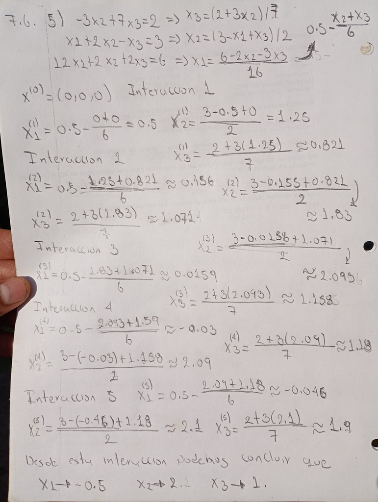

6)

```r
# Sistema 6
A = matrix(c(0.15, 2.11, 30.75,
             0.64, 1.21, 2.05,
             3.21, 1.53, 1.04), nrow = 3, byrow = TRUE)
b = matrix(c(-26.38, 1.01, 5.23), nrow = 3, byrow = TRUE)
Ab <- cbind(A, b); (Ab)
```

```
##      [,1] [,2]  [,3]   [,4]
## [1,] 0.15 2.11 30.75 -26.38
## [2,] 0.64 1.21  2.05   1.01
## [3,] 3.21 1.53  1.04   5.23
```

```r
# Valores iniciales
x1 = 0; x2 = 0; x3 = 0

# Iteraciones Gauss-Seidel
for (iter in 1:50) {
  x1_old = x1; x2_old = x2; x3_old = x3

  x1 = (b[1] - A[1,2]*x2 - A[1,3]*x3) / A[1,1]
  x2 = (b[2] - A[2,1]*x1 - A[2,3]*x3) / A[2,2]
  x3 = (b[3] - A[3,1]*x1 - A[3,2]*x2) / A[3,3]

  cat("Iteración", iter, ": x1 =", round(x1,6), "x2 =", round(x2,6), "x3 =", round(x3,6), "\n")

  if (sqrt((x1 - x1_old)^2 + (x2 - x2_old)^2 + (x3 - x3_old)^2) < 1e-6) break
}
```

```
## Iteración 1 : x1 = -175.8667 x2 = 93.8551 x3 = 409.7728
## Iteración 2 : x1 = -85499.52 x2 = 44529.48 x3 = 198392.9
## Iteración 3 : x1 = -41297095 x2 = 21506972 x3 = 95825012
## Iteración 4 : x1 = -19946658941 x2 = 10387950785 x3 = 46283856256
## Iteración 5 : x1 = -9.634314e+12 x2 = 5.017421e+12 x3 = 2.235528e+13
## Iteración 6 : x1 = -4.653412e+15 x2 = 2.423434e+15 x3 = 1.079769e+16
## Iteración 7 : x1 = -2.247616e+18 x2 = 1.170528e+18 x3 = 5.215326e+18
## Iteración 8 : x1 = -1.085607e+21 x2 = 5.653696e+20 x3 = 2.519023e+21
## Iteración 9 : x1 = -5.243526e+23 x2 = 2.730758e+23 x3 = 1.216698e+24
## Iteración 10 : x1 = -2.532644e+26 x2 = 1.318967e+26 x3 = 5.876699e+26
## Iteración 11 : x1 = -1.223277e+29 x2 = 6.37066e+28 x3 = 2.838469e+29
## Iteración 12 : x1 = -5.908475e+31 x2 = 3.077054e+31 x3 = 1.370991e+32
## Iteración 13 : x1 = -2.853816e+34 x2 = 1.486229e+34 x3 = 6.621942e+34
## Iteración 14 : x1 = -1.378404e+37 x2 = 7.178545e+36 x3 = 3.198424e+37
## Iteración 15 : x1 = -6.657748e+39 x2 = 3.467265e+39 x3 = 1.544851e+40
## Iteración 16 : x1 = -3.215718e+42 x2 = 1.674703e+42 x3 = 7.461693e+42
## Iteración 17 : x1 = -1.553204e+45 x2 = 8.088879e+44 x3 = 3.604027e+45
## Iteración 18 : x1 = -7.502038e+47 x2 = 3.90696e+47 x3 = 1.740759e+48
## Iteración 19 : x1 = -3.623514e+50 x2 = 1.887077e+50 x3 = 8.407934e+50
## Iteración 20 : x1 = -1.750171e+53 x2 = 9.114657e+52 x3 = 4.061065e+53
## Iteración 21 : x1 = -8.453396e+55 x2 = 4.402415e+55 x3 = 1.96151e+56
## Iteración 22 : x1 = -4.083024e+58 x2 = 2.126384e+58 x3 = 9.474172e+58
## Iteración 23 : x1 = -1.972116e+61 x2 = 1.027052e+61 x3 = 4.576062e+61
## Iteración 24 : x1 = -9.525399e+63 x2 = 4.960699e+63 x3 = 2.210256e+64
## Iteración 25 : x1 = -4.600805e+66 x2 = 2.396037e+66 x3 = 1.067562e+67
## Iteración 26 : x1 = -2.222207e+69 x2 = 1.157295e+69 x3 = 5.156368e+69
## Iteración 27 : x1 = -1.073335e+72 x2 = 5.589782e+71 x3 = 2.490546e+72
## Iteración 28 : x1 = -5.184248e+74 x2 = 2.699887e+74 x3 = 1.202943e+75
## Iteración 29 : x1 = -2.504012e+77 x2 = 1.304056e+77 x3 = 5.810263e+77
## Iteración 30 : x1 = -1.209448e+80 x2 = 6.298641e+79 x3 = 2.80638e+80
## Iteración 31 : x1 = -5.84168e+82 x2 = 3.042268e+82 x3 = 1.355493e+83
## Iteración 32 : x1 = -2.821554e+85 x2 = 1.469427e+85 x3 = 6.547082e+85
## Iteración 33 : x1 = -1.362822e+88 x2 = 7.097392e+87 x3 = 3.162266e+88
## Iteración 34 : x1 = -6.582482e+90 x2 = 3.428068e+90 x3 = 1.527387e+91
## Iteración 35 : x1 = -3.179365e+93 x2 = 1.65577e+93 x3 = 7.377339e+93
## Iteración 36 : x1 = -1.535646e+96 x2 = 7.997435e+95 x3 = 3.563284e+96
## Iteración 37 : x1 = -7.417229e+98 x2 = 3.862793e+98 x3 = 1.72108e+99
## Iteración 38 : x1 = -3.58255e+101 x2 = 1.865744e+101 x3 = 8.312883e+101
## Iteración 39 : x1 = -1.730386e+104 x2 = 9.011616e+103 x3 = 4.015155e+104
## Iteración 40 : x1 = -8.357832e+106 x2 = 4.352646e+106 x3 = 1.939336e+107
## Iteración 41 : x1 = -4.036865e+109 x2 = 2.102345e+109 x3 = 9.367067e+109
## Iteración 42 : x1 = -1.949822e+112 x2 = 1.015441e+112 x3 = 4.52433e+112
## Iteración 43 : x1 = -9.417716e+114 x2 = 4.904619e+114 x3 = 2.185269e+115
## Iteración 44 : x1 = -4.548794e+117 x2 = 2.36895e+117 x3 = 1.055494e+118
## Iteración 45 : x1 = -2.197085e+120 x2 = 1.144212e+120 x3 = 5.098075e+120
## Iteración 46 : x1 = -1.061201e+123 x2 = 5.52659e+122 x3 = 2.46239e+123
## Iteración 47 : x1 = -5.125641e+125 x2 = 2.669365e+125 x3 = 1.189344e+126
## Iteración 48 : x1 = -2.475705e+128 x2 = 1.289314e+128 x3 = 5.744579e+128
## Iteración 49 : x1 = -1.195775e+131 x2 = 6.227435e+130 x3 = 2.774654e+131
## Iteración 50 : x1 = -5.77564e+133 x2 = 3.007875e+133 x3 = 1.340169e+134
```

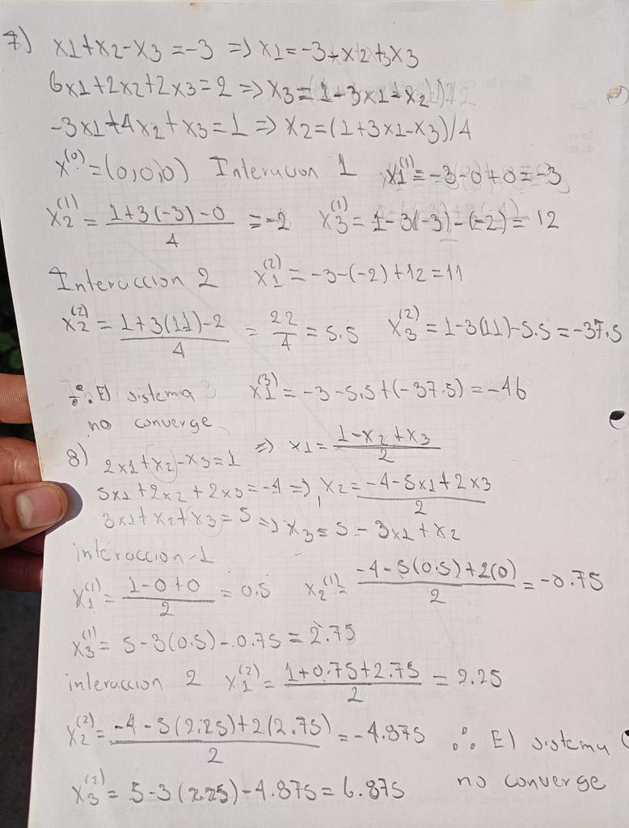

9)

```r
# Sistema 9
A = matrix(c(3, -0.1, -0.2,
             0.1, 7, -0.3,
             0.3, -0.2, 10), nrow = 3, byrow = TRUE)
b = matrix(c(7.85, -19.3, 71.4), nrow = 3, byrow = TRUE)
Ab <- cbind(A, b); (Ab)
```

```
##      [,1] [,2] [,3]   [,4]
## [1,]  3.0 -0.1 -0.2   7.85
## [2,]  0.1  7.0 -0.3 -19.30
## [3,]  0.3 -0.2 10.0  71.40
```

```r
x = 0; y = 0; z = 0

for (iter in 1:50) {
  x_old = x; y_old = y; z_old = z

  x = (b[1] - A[1,2]*y - A[1,3]*z) / A[1,1]
  y = (b[2] - A[2,1]*x - A[2,3]*z) / A[2,2]
  z = (b[3] - A[3,1]*x - A[3,2]*y) / A[3,3]

  cat("Iteración", iter, ": x =", round(x,6), "y =", round(y,6), "z =", round(z,6), "\n")

  if (sqrt((x - x_old)^2 + (y - y_old)^2 + (z - z_old)^2) < 1e-6) break
}
```

```
## Iteración 1 : x = 2.616667 y = -2.794524 z = 7.00561
## Iteración 2 : x = 2.990557 y = -2.499625 z = 7.000291
## Iteración 3 : x = 3.000032 y = -2.499988 z = 6.999999
## Iteración 4 : x = 3 y = -2.5 z = 7
## Iteración 5 : x = 3 y = -2.5 z = 7
```

```r
# Sistema 2
A = matrix(c(17, -2, -3,
             -5, 21, -2,
             -5, -5, 22), nrow = 3, byrow = TRUE)
b = matrix(c(500, 200, 30), nrow = 3, byrow = TRUE)
Ab <- cbind(A, b); (Ab)
```

```
##      [,1] [,2] [,3] [,4]
## [1,]   17   -2   -3  500
## [2,]   -5   21   -2  200
## [3,]   -5   -5   22   30
```

```r
x1 = 0; x2 = 0; x3 = 0

for (iter in 1:50) {
  x1_old = x1; x2_old = x2; x3_old = x3

  x1 = (b[1] - A[1,2]*x2 - A[1,3]*x3) / A[1,1]
  x2 = (b[2] - A[2,1]*x1 - A[2,3]*x3) / A[2,2]
  x3 = (b[3] - A[3,1]*x1 - A[3,2]*x2) / A[3,3]

  cat("Iteración", iter, ": x1 =", round(x1,6), "x2 =", round(x2,6), "x3 =", round(x3,6), "\n")

  if (sqrt((x1 - x1_old)^2 + (x2 - x2_old)^2 + (x3 - x3_old)^2) < 1e-6) break
}
```

```
## Iteración 1 : x1 = 29.41176 x2 = 16.52661 x3 = 11.80418
## Iteración 2 : x1 = 33.43916 x2 = 18.60972 x3 = 13.19293
## Iteración 3 : x1 = 33.92931 x2 = 18.85869 x3 = 13.36091
## Iteración 4 : x1 = 33.98824 x2 = 18.88872 x3 = 13.38113
## Iteración 5 : x1 = 33.99534 x2 = 18.89233 x3 = 13.38356
## Iteración 6 : x1 = 33.9962 x2 = 18.89277 x3 = 13.38386
## Iteración 7 : x1 = 33.9963 x2 = 18.89282 x3 = 13.38389
## Iteración 8 : x1 = 33.99631 x2 = 18.89283 x3 = 13.3839
## Iteración 9 : x1 = 33.99631 x2 = 18.89283 x3 = 13.3839
## Iteración 10 : x1 = 33.99631 x2 = 18.89283 x3 = 13.3839
```

### Gauss-Jacobi

#### Ejercicio 7.7.

```r
# Sistema 1

A <- matrix(c(
  10, 2, -1, 0,
   1, 20, -2, 3,
  -2, 1, 30, 0,
   1, 2, 3, 20
), nrow = 4, byrow = TRUE)

b <- c(26, -15, 53, 47)

# Valores iniciales
x <- c(0, 0, 0, 0)

cat("Iteración |     x1       x2       x3       x4\n")
```

```
## Iteración |     x1       x2       x3       x4
```

```r
cat("-----------------------------------------------\n")
for (k in 1:15) {
  x_new <- numeric(4)

  x_new[1] <- (26 - 2*x[2] + x[3]) / 10
  x_new[2] <- (-15 - x[1] + 2*x[3] - 3*x[4]) / 20
  x_new[3] <- (53 + 2*x[1] - x[2]) / 30
  x_new[4] <- (47 - x[1] - 2*x[2] - 3*x[3]) / 20

  cat(sprintf("%5d     %9.6f %9.6f %9.6f %9.6f\n",
              k, x_new[1], x_new[2], x_new[3], x_new[4]))

  x <- x_new
}
```

```
##     1      2.600000 -0.750000  1.766667  2.350000
##     2      2.926667 -1.055833  1.965000  2.030000
##     3      3.007667 -1.004333  1.996972  2.014500
##     4      3.000564 -1.002861  2.000656  2.000504
##     5      3.000638 -1.000038  2.000133  2.000160
##     6      3.000021 -1.000043  2.000044  1.999952
##     7      3.000013 -0.999989  2.000003  1.999997
##     8      2.999998 -1.000000  2.000001  1.999998
##     9      3.000000 -1.000000  2.000000  2.000000
##    10      3.000000 -1.000000  2.000000  2.000000
##    11      3.000000 -1.000000  2.000000  2.000000
##    12      3.000000 -1.000000  2.000000  2.000000
##    13      3.000000 -1.000000  2.000000  2.000000
##    14      3.000000 -1.000000  2.000000  2.000000
##    15      3.000000 -1.000000  2.000000  2.000000
```

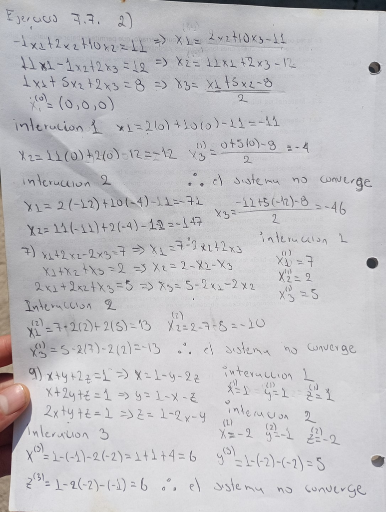

Ejercicio 2 Gauss-Jacobi

```r
# Sistema 3

A <- matrix(c(
  8, 2, 3,
  2, 5, 1,
 -3, 1, 6
), nrow = 3, byrow = TRUE)

b <- c(51, 23, 20)

# Valores iniciales
x <- c(0, 0, 0)

cat("Iteración |     x1       x2       x3\n")
```

```
## Iteración |     x1       x2       x3
```

```r
cat("-----------------------------------------\n")
for (k in 1:15) {
  x_new <- numeric(3)

  x_new[1] <- (51 - 2*x[2] - 3*x[3]) / 8
  x_new[2] <- (23 - 2*x[1] - x[3]) / 5
  x_new[3] <- (20 + 3*x[1] - x[2]) / 6

  cat(sprintf("%5d     %9.6f %9.6f %9.6f\n",
              k, x_new[1], x_new[2], x_new[3]))

  x <- x_new
}
```

```
##     1      6.375000  4.600000  3.333333
##     2      3.975000  1.383333  5.754167
##     3      3.871354  1.859167  5.090278
##     4      4.001354  2.033403  4.959149
##     5      4.006968  2.007628  4.995110
##     6      3.999927  1.998191  5.002213
##     7      3.999623  1.999587  5.000265
##     8      4.000004  2.000098  4.999880
##     9      4.000020  2.000022  4.999986
##    10      4.000000  1.999995  5.000006
##    11      3.999999  1.999999  5.000001
##    12      4.000000  2.000000  5.000000
##    13      4.000000  2.000000  5.000000
##    14      4.000000  2.000000  5.000000
##    15      4.000000  2.000000  5.000000
```

```r
# Sistema 4
A <- matrix(c(
  2, -1, 1, 3,
  2, 2, 2, 2,
 -1, -1, 2, 2,
  3, 1, -1, 4
), nrow = 4, byrow = TRUE)

b <- c(10, 1, -5, 6)

x <- c(0, 0, 0, 0)

cat("Iter |      x1        x2        x3        x4\n")
```

```
## Iter |      x1        x2        x3        x4
```

```r
cat("----------------------------------------------\n")
for (k in 1:15) {
  x_new <- numeric(4)

  x_new[1] <- (10 + x[2] - x[3] - 3*x[4]) / 2
  x_new[2] <- (1 - 2*x[1] - 2*x[3] - 2*x[4]) / 2
  x_new[3] <- (-5 + x[1] + x[2] - 2*x[4]) / 2
  x_new[4] <- (6 - 3*x[1] - x[2] + x[3]) / 4

  cat(sprintf("%4d   %10.6f %10.6f %10.6f %10.6f\n",
              k, x_new[1], x_new[2], x_new[3], x_new[4]))

  x <- x_new
}
```

```
##    1     5.000000   0.500000  -2.500000   1.500000
##    2     4.250000  -3.500000  -1.250000  -3.000000
##    3     8.375000   0.500000   0.875000  -1.125000
##    4     6.500000  -7.625000   3.062500  -4.687500
##    5     6.687500  -4.375000   1.625000  -0.703125
##    6     3.054688  -7.109375  -0.640625  -2.015625
##    7     4.789062   0.101562  -2.511719   0.826172
##    8     5.067383  -2.603516  -0.880859  -2.745117
##    9     8.256348  -0.941406   1.477051  -1.869873
##   10     6.595581  -7.363525   3.027344  -4.087646
##   11     5.936035  -5.035278   1.203674  -0.848969
##   12     3.153976  -5.790741  -1.200653  -1.392288
##   13     4.793388  -0.061035  -2.426094   0.282040
##   14     5.759470  -2.149334  -0.415863  -2.686306
##   15     8.162724  -2.157301   1.991374  -2.386235
```

```r
# Sistema 5
A <- matrix(c(
  3, 1, 1, -1,
  0, 2, 1, 4,
  1, 1, -1, 9,
  2, 4, 6, 3
), nrow = 4, byrow = TRUE)

b <- c(5, 0, 1, 0)

x <- c(0, 0, 0, 0)

cat("Iter |      x1        x2        x3        x4\n")
```

```
## Iter |      x1        x2        x3        x4
```

```r
cat("----------------------------------------------\n")
for (k in 1:15) {
  x_new <- numeric(4)

  x_new[1] <- (5 - x[2] - x[3] + x[4]) / 3
  x_new[2] <- (0 - x[3] - 4*x[4]) / 2
  x_new[3] <- (1 - x[1] - x[2] - 9*x[4]) / (-1)
  x_new[4] <- (0 - 2*x[1] - 4*x[2] - 6*x[3]) / 3

  cat(sprintf("%4d   %10.6f %10.6f %10.6f %10.6f\n",
              k, x_new[1], x_new[2], x_new[3], x_new[4]))

  x <- x_new
}
```

```
##    1     1.666667   0.000000  -1.000000   0.000000
##    2     2.000000   0.500000   0.666667   0.888889
##    3     1.574074  -2.111111   9.500000  -3.333333
##    4    -1.907407   1.916667 -31.537037 -17.234568
##    5     5.795267  50.237654 -156.101852  61.790123
##    6    57.551440 -45.529321 611.144033 241.356653
##    7   -106.419353 -788.285322 2183.231996 -1199.949931
##    8   -863.298868 1308.283865 -11695.254058 -3244.470660
##    9   2382.499844 12336.568349 -28756.250943 22221.662209
##   10   12882.114934 -30065.198945 214713.028070 39475.410858
##   11   -48389.139422 -186307.335751 338094.613710 -397927.200835
##   12   -183236.492932 626807.094816 -3816042.282691 -395520.020138
##   13   931240.055913 2699061.181621 -3116110.579355 6918499.434249
##   14   2445184.610661 -12278943.578820 65896795.145772 2012646.212608
##   15   -17201733.451448 -36973689.998101 8280055.945311 -117051788.593558
```

```r
# Por lo tanto el sistema no converge
```

```r
# Sistema 6
A <- matrix(c(
  10, -1,  2, 0,
  -1, 11, -1, 3,
   2, -1, 10, -1,
   0,  2, -1, 8
), nrow = 4, byrow = TRUE)

b <- c(6, 25, -11, 15)

x <- c(0, 0, 0, 0)

cat("Iter |      x1        x2        x3        x4\n")
```

```
## Iter |      x1        x2        x3        x4
```

```r
cat("----------------------------------------------\n")
for (k in 1:15) {
  x_new <- numeric(4)

  x_new[1] <- (6 + x[2] - 2*x[3]) / 10
  x_new[2] <- (25 + x[1] + x[3] - 3*x[4]) / 11
  x_new[3] <- (-11 - 2*x[1] + x[2] + x[4]) / 10
  x_new[4] <- (15 - 2*x[2] + x[3]) / 8

  cat(sprintf("%4d   %10.6f %10.6f %10.6f %10.6f\n",
              k, x_new[1], x_new[2], x_new[3], x_new[4]))

  x <- x_new
}
```

```
##    1     0.600000   2.272727  -1.100000   1.875000
##    2     1.047273   1.715909  -0.805227   1.169318
##    3     0.932636   1.975826  -1.020932   1.345369
##    4     1.001769   1.897782  -0.954408   1.253427
##    5     0.980660   1.935189  -0.985233   1.281254
##    6     0.990566   1.922879  -0.974488   1.268049
##    7     0.987185   1.928357  -0.979020   1.272469
##    8     0.988640   1.926432  -0.977354   1.270533
##    9     0.988114   1.927244  -0.978031   1.271223
##   10     0.988331   1.926947  -0.977776   1.270935
##   11     0.988250   1.927068  -0.977878   1.271041
##   12     0.988282   1.927023  -0.977839   1.270998
##   13     0.988270   1.927041  -0.977854   1.271014
##   14     0.988275   1.927034  -0.977848   1.271008
##   15     0.988273   1.927037  -0.977851   1.271010
```

```r
# Sistema 8

A <- matrix(c(
  -4, 14, 0,
  -5, 13, 0,
  -1,  0, 2
), nrow = 3, byrow = TRUE)

b <- c(10, 8, 1)

x <- c(0, 0, 0)

cat("Iter |      x1        x2        x3\n")
```

```
## Iter |      x1        x2        x3
```

```r
cat("-------------------------------------\n")
for (k in 1:15) {

  x_new <- numeric(3)

  x_new[1] <- (b[1] - 14*x[2]) / (-4)
  x_new[2] <- (b[2] + 5*x[1]) / 13
  x_new[3] <- (b[3] + x[1]) / 2

  cat(sprintf("%4d   %10.6f %10.6f %10.6f\n",
              k, x_new[1], x_new[2], x_new[3]))

  x <- x_new
}
```

```
##    1    -2.500000   0.615385   0.500000
##    2    -0.346154  -0.346154  -0.750000
##    3    -3.711538   0.482249   0.326923
##    4    -0.812130  -0.812130  -1.355769
##    5    -5.342456   0.303027   0.093935
##    6    -1.439406  -1.439406  -2.171228
##    7    -7.537921   0.061767  -0.219703
##    8    -2.283816  -2.283816  -3.268961
##    9   -10.493355  -0.263006  -0.641908
##   10    -3.420521  -3.420521  -4.746678
##   11   -14.471824  -0.700200  -1.210261
##   12    -4.950702  -4.950702  -6.735912
##   13   -19.827456  -1.288731  -1.975351
##   14    -7.010560  -7.010560  -9.413728
##   15   -27.036960  -2.080985  -3.005280
```

```r
# Sistema 10

A <- matrix(c(
   6, -2,  2,  4,
  12, -8,  6, 10,
   3, -13, 9,  3,
  -6,  4,  1, -18
), nrow = 4, byrow = TRUE)

b <- c(10, 20, 2, -19)

x <- c(0, 0, 0, 0)

cat("Iter |      x1        x2        x3        x4\n")
```

```
## Iter |      x1        x2        x3        x4
```

```r
cat("----------------------------------------------\n")
for (k in 1:15) {

  x_new <- numeric(4)

  x_new[1] <- (b[1] + 2*x[2] - 2*x[3] - 4*x[4]) / 6
  x_new[2] <- (b[2] - 12*x[1] - 6*x[3] - 10*x[4]) / (-8)
  x_new[3] <- (b[3] - 3*x[1] + 13*x[2] - 3*x[4]) / 9
  x_new[4] <- (b[4] + 6*x[1] - 4*x[2] - x[3]) / (-18)

  cat(sprintf("%4d   %10.6f %10.6f %10.6f %10.6f\n",
              k, x_new[1], x_new[2], x_new[3], x_new[4]))

  x <- x_new
}
```

```
##    1     1.666667  -2.500000   0.222222   1.055556
##    2     0.055556   1.486111  -4.296296  -0.043210
##    3     3.622942  -5.692901   2.364712   1.128601
##    4    -1.771605   6.118699  -9.584705  -1.285808
##    5     7.758340 -13.953196  10.079480   2.473318
##    6    -7.993104  19.788767 -23.342947  -4.071297
##    7    18.758103 -37.085988  32.827464   6.820597
##    8   -26.184882  58.783499 -61.872660 -11.614728
##    9    49.628538 -102.700228  97.731590  19.409479
##   10   -78.083592 169.503349 -171.135224 -32.880031
##   11   137.132878 -289.076844 282.048267  55.243318
##   12   -225.537249 483.789665 -481.458618 -93.225354
##   13   385.566331 -818.431530 805.283717 156.995752
##   14   -644.235584 1376.056974 -1362.810683 -264.602244
##   15   1091.024048 -2321.714192 2290.806016 445.879484
```

### Ejercicio 7.8

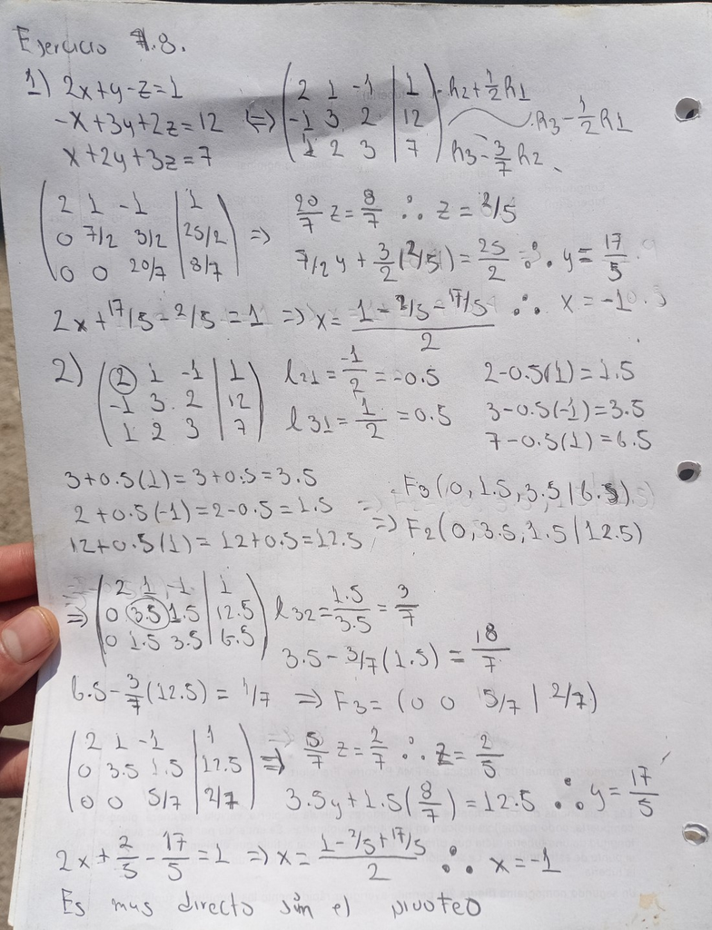

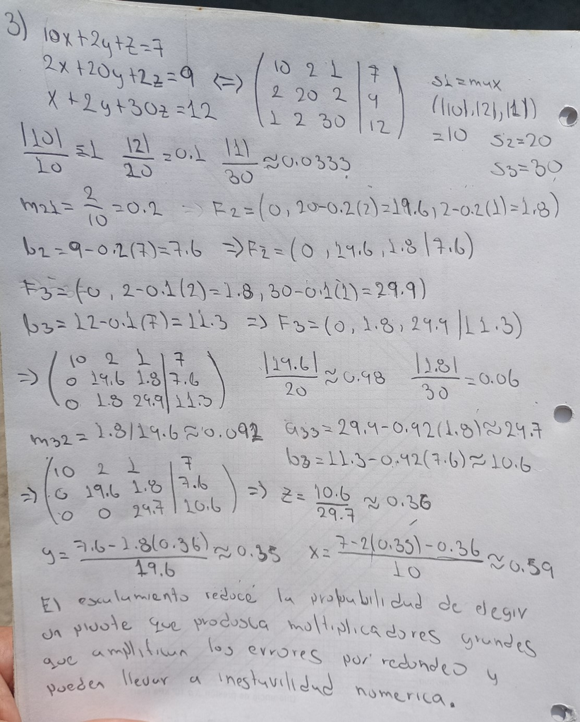

```r
# Matriz original
A <- matrix(c(1, 2, 1,
              0, 1, -1,
              2, 3, 4), nrow = 3, byrow = TRUE)

# Augmentamos con la identidad
AI <- cbind(A, diag(3))

# Aplicamos Gauss–Jordan manualmente
gauss_jordan_inverse <- function(AI) {
  n <- nrow(AI)
  for (i in 1:n) {
    # Pivoteo parcial si es necesario
    if (AI[i, i] == 0) {
      for (j in (i+1):n) {
        if (AI[j, i] != 0) {
          AI[c(i, j), ] <- AI[c(j, i), ]
          break
        }
      }
    }
    # Normalizamos la fila
    AI[i, ] <- AI[i, ] / AI[i, i]
    # Eliminamos otras entradas en la columna
    for (j in 1:n) {
      if (j != i) {
        AI[j, ] <- AI[j, ] - AI[j, i] * AI[i, ]
      }
    }
  }
  return(AI[, (n+1):(2*n)])
}

A_inv <- gauss_jordan_inverse(AI)
print(A_inv)
```

```
##      [,1] [,2] [,3]
## [1,]    7   -5   -3
## [2,]   -2    2    1
## [3,]   -2    1    1
```

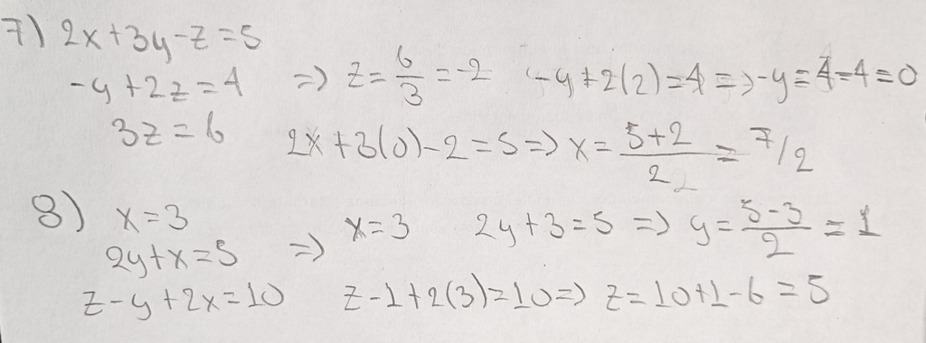

Ejercicio 7 y 8 Sustitucion hacia atras/adelante

```r
# Sistema Ax = b
A <- matrix(c(10, -1, 2, 0,
              -1, 11, -1, 3,
              2, -1, 10, -1,
              0, 3, -1, 8), nrow = 4, byrow = TRUE)
b <- c(6, 25, -11, 15)

# Inicialización
x_old <- rep(0, 4)
jacobi_iter <- function(A, b, x0, iter) {
  n <- length(b)
  x <- x0
  for (k in 1:iter) {
    x_new <- numeric(n)
    for (i in 1:n) {
      suma <- sum(A[i, -i] * x[-i])
      x_new[i] <- (b[i] - suma) / A[i, i]
    }
    cat("Iteración", k, ": ", round(x_new, 6), "\n")
    x <- x_new
  }
  return(x)
}

x_jacobi <- jacobi_iter(A, b, x_old, 3)
```

```
## Iteración 1 :  0.6 2.272727 -1.1 1.875
## Iteración 2 :  1.047273 1.715909 -0.805227 0.885227
## Iteración 3 :  0.932636 2.053306 -1.049341 1.130881
```

```r
# Matriz A y vector b
A <- matrix(c(4, 1,
              1, 3), nrow = 2, byrow = TRUE)
b <- c(9, 7)

# Descomposición A = D + L + U
D <- diag(diag(A))
L <- A - D
T_J <- -solve(D) %*% L
c_J <- solve(D) %*% b

# Verificar radio espectral
rho <- max(Mod(eigen(T_J)$values))

cat("T_J:\n"); print(round(T_J, 4))
```

```
## T_J:
```

```
##         [,1]  [,2]
## [1,]  0.0000 -0.25
## [2,] -0.3333  0.00
```

```r
cat("c_J:\n"); print(round(c_J, 4))
```

```
## c_J:
```

```
##        [,1]
## [1,] 2.2500
## [2,] 2.3333
```

```r
cat("Radio espectral rho(T_J):", round(rho, 4), "\n")
```

```
## Radio espectral rho(T_J): 0.2887
```

# Raices de funciones

## Método de la bicceción

```r
A <- 1
B <- -6
C <- 11
D <- -6

f <- function(x) {
  A*x^3 + B*x^2 + C*x + D
}

a1 <- 0
b1 <- 2.5

c1 <- (a1 + b1)/2
fa1 <- f(a1)
fb1 <- f(b1)
fc1 <- f(c1)
s1a <- sign(fa1 * fc1)
s1b <- sign(fb1 * fc1)
e1 <- (b1 - a1)/2
a2 <- if (fa1 * fc1 < 0) a1 else c1
b2 <- if (fa1 * fc1 < 0) c1 else b1

c2 <- (a2 + b2)/2
fa2 <- f(a2)
fb2 <- f(b2)
fc2 <- f(c2)
s2a <- sign(fa2 * fc2)
s2b <- sign(fb2 * fc2)
e2 <- (b2 - a2)/2
a3 <- if (fa2 * fc2 < 0) a2 else c2
b3 <- if (fa2 * fc2 < 0) c2 else b2

c3 <- (a3 + b3)/2
fa3 <- f(a3)
fb3 <- f(b3)
fc3 <- f(c3)
s3a <- sign(fa3 * fc3)
s3b <- sign(fb3 * fc3)
e3 <- (b3 - a3)/2
a4 <- if (fa3 * fc3 < 0) a3 else c3
b4 <- if (fa3 * fc3 < 0) c3 else b3

c4 <- (a4 + b4)/2
fa4 <- f(a4)
fb4 <- f(b4)
fc4 <- f(c4)
s4a <- sign(fa4 * fc4)
s4b <- sign(fb4 * fc4)
e4 <- (b4 - a4)/2
a5 <- if (fa4 * fc4 < 0) a4 else c4
b5 <- if (fa4 * fc4 < 0) c4 else b4

c5 <- (a5 + b5)/2
fa5 <- f(a5)
fb5 <- f(b5)
fc5 <- f(c5)
s5a <- sign(fa5 * fc5)
s5b <- sign(fb5 * fc5)
e5 <- (b5 - a5)/2
a6 <- if (fa5 * fc5 < 0) a5 else c5
b6 <- if (fa5 * fc5 < 0) c5 else b5

c6 <- (a6 + b6)/2
fa6 <- f(a6)
fb6 <- f(b6)
fc6 <- f(c6)
s6a <- sign(fa6 * fc6)
s6b <- sign(fb6 * fc6)
e6 <- (b6 - a6)/2

raiz_aprox <- c6
error_cota <- e6

cat("Raíz aproximada (6 iteraciones):", raiz_aprox, "\n")
```

```
## Raíz aproximada (6 iteraciones): 0.9765625
```

```r
cat("Cota máxima del error:", error_cota, "\n\n")
```

```
## Cota máxima del error: 0.0390625
```

```r
iter <- 1:6
Acol <- c(a1,a2,a3,a4,a5,a6)
Bcol <- c(b1,b2,b3,b4,b5,b6)
Ccol <- c(c1,c2,c3,c4,c5,c6)
FA <- c(fa1,fa2,fa3,fa4,fa5,fa6)
FB <- c(fb1,fb2,fb3,fb4,fb5,fb6)
FC <- c(fc1,fc2,fc3,fc4,fc5,fc6)
signFAFC <- c(s1a,s2a,s3a,s4a,s5a,s6a)
signFBFC <- c(s1b,s2b,s3b,s4b,s5b,s6b)
ERR <- c(e1,e2,e3,e4,e5,e6)

TAB <- data.frame(
  iter,
  a = Acol,
  b = Bcol,
  c = Ccol,
  fa = FA,
  fb = FB,
  fc = FC,
  sign_fa_fc = signFAFC,
  sign_fb_fc = signFBFC,
  error = ERR
)

print(round(TAB, 6))
```

```
##   iter      a        b        c        fa        fb        fc sign_fa_fc
## 1    1 0.0000 2.500000 1.250000 -6.000000 -0.375000  0.328125         -1
## 2    2 0.0000 1.250000 0.625000 -6.000000  0.328125 -1.224609          1
## 3    3 0.6250 1.250000 0.937500 -1.224609  0.328125 -0.136963          1
## 4    4 0.9375 1.250000 1.093750 -0.136963  0.328125  0.161957         -1
## 5    5 0.9375 1.093750 1.015625 -0.136963  0.161957  0.030521         -1
## 6    6 0.9375 1.015625 0.976562 -0.136963  0.030521 -0.048536          1
##   sign_fb_fc    error
## 1         -1 1.250000
## 2         -1 0.625000
## 3         -1 0.312500
## 4          1 0.156250
## 5          1 0.078125
## 6         -1 0.039062
```

## Método de la secante

```r
f <- function(x) {
  cos(x) - x
}

x0 <- 0
x1 <- 1

f0 <- f(x0)
f1 <- f(x1)

x2 <- x1 - f1*(x1 - x0)/(f1 - f0)
f2 <- f(x2)
e1 <- abs(x2 - x1)

x3 <- x2 - f2*(x2 - x1)/(f2 - f1)
f3 <- f(x3)
e2 <- abs(x3 - x2)

x4 <- x3 - f3*(x3 - x2)/(f3 - f2)
f4 <- f(x4)
e3 <- abs(x4 - x3)

x5 <- x4 - f4*(x4 - x3)/(f4 - f3)
f5 <- f(x5)
e4 <- abs(x5 - x4)

x6 <- x5 - f5*(x5 - x4)/(f5 - f4)
f6 <- f(x6)
e5 <- abs(x6 - x5)

x7 <- x6 - f6*(x6 - x5)/(f6 - f5)
f7 <- f(x7)
e6 <- abs(x7 - x6)

raiz_aprox <- x7
error_cota <- e6

cat("Raíz aproximada (6 iteraciones):", raiz_aprox, "\n")
```

```
## Raíz aproximada (6 iteraciones): 0.7390851
```

```r
cat("Cota máxima del error:", error_cota, "\n\n")
```

```
## Cota máxima del error: 1.59428e-13
```

```r
iter <- 1:6
Xn_1 <- c(x0, x1, x2, x3, x4, x5)
Xn   <- c(x1, x2, x3, x4, x5, x6)
Xn1  <- c(x2, x3, x4, x5, x6, x7)
Fn_1 <- c(f0, f1, f2, f3, f4, f5)
Fn   <- c(f1, f2, f3, f4, f5, f6)
Fn1  <- c(f2, f3, f4, f5, f6, f7)
ERR  <- c(e1, e2, e3, e4, e5, e6)

TAB <- data.frame(
  iter,
  x_prev = Xn_1,
  x_curr = Xn,
  x_next = Xn1,
  f_prev = Fn_1,
  f_curr = Fn,
  f_next = Fn1,
  error = ERR
)

print(round(TAB, 6))
```

```
##   iter   x_prev   x_curr   x_next    f_prev    f_curr    f_next    error
## 1    1 0.000000 1.000000 0.685073  1.000000 -0.459698  0.089299 0.314927
## 2    2 1.000000 0.685073 0.736299 -0.459698  0.089299  0.004660 0.051226
## 3    3 0.685073 0.736299 0.739119  0.089299  0.004660 -0.000057 0.002820
## 4    4 0.736299 0.739119 0.739085  0.004660 -0.000057  0.000000 0.000034
## 5    5 0.739119 0.739085 0.739085 -0.000057  0.000000  0.000000 0.000000
## 6    6 0.739085 0.739085 0.739085  0.000000  0.000000  0.000000 0.000000
```